# Predicting Illegal Rentals in Philadlephia

Jessica Klion, Fay Walker, Angelica Kim

March 27, 2019

## R Markdown

**1.0 Introduction**

*1.1 How to use this document*

*1.2 Abstract*

Matthew Desmond’s Evicted: Poverty and Profit in the American City shed light on the extent of the eviction crisis across the United States. In Philadelphia, rental prices have gone up by 10 percent in less than ten years and wages have not kept up. As a result, according to the United States Census, over half of renters are rent-burdened (qualifying as spending over one-third of salary on housing), and nearly one-third of these renters spend over 50 percent of their salary on housing. As more and more people are rent-burdened, evictions become more and more common, with failure to pay being the lead cause.

Evictions bear real downstream costs and implications, particularly because they impact single-mothers, low-income, and black households disproportionately. Additionally, eviction is a leading contributing cause of homelessness. In September 2017, Mayor Jim Kenney created the Mayor’s Task Force for Eviction Prevention and Response to further explore the over 24,000 evictions Philadelphia saw in 2016 alone. This number does not account for people who were illegally evicted, and while that number is unknown, in cities such as Milwaukee, including illegal evictions can double the total eviction rate.

Evictions refer to a legal process that provides tenants with rights. These rights mean that owners cannot lock tenants out of their homes, they must provide formal notice, and they must go through a court process to remove a tenant from a rental property. However, illegal evictions occur outside of this court process. In Philadelphia, to rent out a property, an owner must obtain a rental license, which requires, among other things, for the home to be up to code and safe to live in. Despite this requirement, thousands of homes in Philadelphia are rented without a license, which leaves the tenant with minimal protection. These illegal rentals can lack formal leases which allows the landlord to act on a whim, rather than by abiding to a formal process. This can lead to illegal evictions, which are particularly insidious because they leave tenants with limited legal recourse and protection. With no official record of the rental and the eviction, it is difficult to distill how often landlords are renting out their properties without a proper license.

Currently, Licenses and Inspections conducts inspections (which would identify illegal rentals) in an ad hoc fashion. There are limited inspectors and a backlog for inspections. Given this, L&I must be able to prioritize when and where they conduct inspections. The tool developed through this analysis predicts the probability that a property is being rented to a tenant without a rental license for all non-owner occupied homes in Philadelphia in order to help L&I better prioritize inspections.

*1.3 Motivation*

Between 2009 to 2016, rental prices in Philadelphia went up by 10 percent, while wages only went up by 0.3 percent. As a result, over half of Philly renters are rent-burdened (qualifying as spending over one-third of salary on housing), and nearly one-third of these renters spend over 50 percent of their salary on housing. As more and more people are rent-burdened, evictions become more and more common, with failure to pay being the lead cause of eviction. In 2016 alone, there were 24,000 evictions. Evictions bear real implications, particularly because they impact single-mothers, low-income, and black households disproportionately.

Evictions are a pressing issue in Philadelphia, so much so that Mayor Jim Kenney established the Mayor’s Task Force for Eviction Prevention and Response in September 2017, with the intention of developing an understanding of evictions in Philadelphia, determining best practices, identifying new funding streams to support task force activities, and producing a report and actionable recommendations to reduce evictions (Philadelphia Department of Health and Human Services, “Mayor’s Task Force on Eviction Prevention and Response”).

As rental prices rise and evictions become more frequent in the city, so too does homelessness. There are an estimated 5,700 homeless people in Philadelphia, and about 20 percent of people in shelters list eviction as a cause of homelessness.

Eviction is a legal process that provides tenants with rights. This means that owners cannot lock tenants out of their homes, they must provide notice, and they must go through the court process to remove a tenant from a rental property. In 2016, there were 24,000 evictions, accounting for 9 percent of households in Philadelphia (Mayor’s Task Force Report).

In Philadelphia, all rental units are required to be certified prior to leasing. Through certification, landlords must obtain a rental license. If a unit is not certified, but is still rented out, it is considered an illegal rental. In other words, a landlord is renting their units under the table, and as a result, the eviction process also happens under the table. Illegal rentals are dangerous because they leave tenants without legal recourse. If tenants are evicted from a property that is not licensed then they do not have to be given notice, and they cannot make their case in court.

With no official record of the rental and the eviction, it is difficult to distill how often landlords are renting out their properties without a proper license. These rentals without licenses pose a risk of not only illegal evictions, but also of code violations. In 2017, one in five eviction cases filed in Philadelphia was connected to a property where a code violation was issued within a year, potentially showing that there is value in examining the relationship between code violations and illegal rentals.

The only record we have for illegal rentals is of the Department of License and Inspections (L&I) Code Violation 9-3902; renting without a license, but this number is far underestimating the problem, and the 24,000 evictions Philly saw in 2016 does not account for illegal evictions. In cities such as Milwaukee, accounting for illegal evictions can increase eviction counts two-fold.

Currently, L&I conducts inspections in an ad hoc fashion. There are limited inspectors and a backlog for inspections. Given this, L&I must be able to prioritize when and where they conduct inspections, this tool will develop a model to predict the probability that a property is being rented to a tenant without a rental license for all non-owner occupied homes in Philadelphia in order to help L&I better prioritize inspections.

*1.4 Methods in Brief*  
This analysis was built off of publicly available data, largely from Philadelphia’s open data website. Once gathered, we used feature engineering to create variables for our analysis. We then conducted an exploratory analysis of our data to better understand the nature of rentals, evictions, and illegal rentals in Philadelphia. Once all of our data was consolidated and cleaned we built a predictive model that provides an illegal rental risk score for all rental homes in Philadelphia.

*1.5 Data*  
A primary challenge in this analysis was creating one cohesive dataset based off of disparate and unstandardized administrative data. To develop this dataset we pulled data from the following sources:

- Licensing and Inspection Code Violations (from Licenses and Inspections via OpenDataPhilly)
- Business Licenses (from Licenses and Inspections via OpenDataPhilly)
- Property Assessments (from the Office of Property Assessment via OpenDataPhilly)

Additional data was collected that inform both our exploratory analysis and our model development. This included the following data:

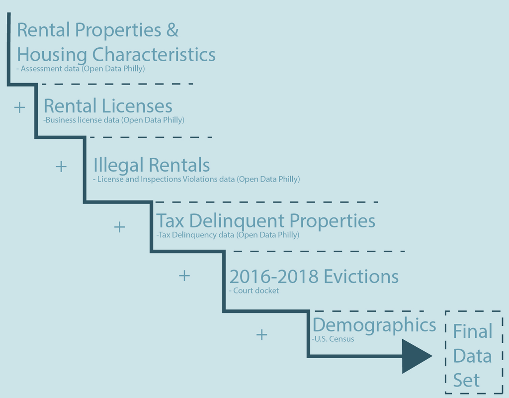

*Data and Data Sources*

**2.0 Data Wrangling and Cleaning**  
The following presents an overview of how we developed a cohesive dataset from the many necessary datasets for our analysis. This process required extensive work to ultimately get a dataset that is usable and manageable.

*2.1 Data Cleaning*

Office of Property Assessment (OPA) Data  
The final dataset for this analysis includes all potentially rental properties in Philadelphia. To create this dataset, we began with the Office of Property Assessment data, which includes information on every parcel in Philadelphia. The full dataset from 2018 included over 600,000 rows. To cull it down to just residential rental properties, we began by selecting out the rows where parcels were zoned residential. This cut the dataset down to about 500,000 observations. The following zoning categories were kept in the dataset:

- Residential single-family detached homes (RSD)
- Residential single-family attached districts (RSA)
- Residential two-family attached districts (RTA)
- Residential multi-family districts (RM)
- Residential mixed-use districts (RMX)

Following this cut, which provides a dataset of residential parcels in Philadelphia, the OPA dataset was further cut down to exclude known owner-occupied properties. While the designation of owner-occupied homes is not explicitly included in the OPA dataset, it could be proxied. For this analysis, owner occupied homes were proxied as those that received a homestead exemption tax break, which is included in the OPA data. This cut the dataset down to about 300,000 rows.

For this analysis, the OPA dataset served as our primary datasource and where we derived the majority of features for our model. Once cleaned, all of our datasets were joined to this dataset as it was the largest.

Business License Data  
The business license data included about 300,000 unique observations for every business license issued by the City of Philadelphia for over 10 years, with some data going back as far as 2000. The dataset included information on license type, license status, license issue date, and license holder. The first step in managing this dataset was to limit the data to just 2016 to 2018. From there, we further cut the data down by selecting out those rows where a residential rental license was issued. This cut the data down to about 160,000 rows. Note that this vacant residential properties were left in the dataset. Unneeded columns were removed from this dataset and then it was ready to join to the OPA dataset.

Office of License and Inspections Violations Data  
The data on violations from L&I included over 1 million unique observations for every violation that the office had issued since 2007. This dataset is particularly important for our analysis because it contains the independent variable for our model: illegal rental violation (code: 9-3902). In addition to this information, this dataset included information on when violations were issued, who they were issued to, and violations status. Like with the business license data, the first step in managing this dataset was to limit the dataset to only years to 2016-2018. This left us with 340,684 observations. Before joining, but following feature engineering, we cut the dataset down so that each row represented one property. In other words, for those properties that had multiple violations, we selected out just one row, so that our join would work. In performing this cut after feature engineering, we were able to capture if a property had multiple violations, as we included a feature for total number of violations. From there, unneeded columns were removed and the data was ready to join.

United States Census Data  
This dataset contained demographic information from the American Community Survey using 2013-2017 census tract level data. It is worth noting that this is our only data that is not a the parcel level. We pulled the following demographics that we deemed of interest:

- Percent foreign-born
- Percent black
- Percent non-white
- Percent renters
- Percent High rent-burden
- Percent below-poverty level
- Percent single-mother households
- Elevated Blood Lead Level Indicators (this was pulled from OpenData, not from the Census, but it was gathered at the tract level and joined to the census csv)

Court Docket Data  
The court docket data includes all eviction cases in the City of Philadelphia from 2016 to 2018. The docket included extensive information regarding each eviction case, including plaintiff and defendant, case data, and case status. We removed unnecessary columns from the dataset prior to joining with the rest of our data.

Azavea Neighborhoods  
The final dataset included in our analysis was a spatial dataset of neighborhoods in Philadelphia. This provides spatial information on neighborhood boundaries and required no cleaning prior to joining. However, this dataset is useful in both our exploratory analysis and in our spatial model.

Prior to joining the datasets to the OPA dataset, we had to do some additional cleaning Importantly, we had to identify and remove the NAs and missing information from each column. To do so, we first calculated where the NAs and missing data were and then made a fixed effect for each variable with missing information, which accounts for the fact that we do not have information on this variable for this property. We then made the missing information and NAs zero in each column where they existed, as the model needs data to run.

*2.2 Data Wrangling*  
We then proceeded as follows to join the numerous datasets together:

- Join 1: Left Joined OPA Dataset with our L&I licensing dataset. Used OPA Account number as unique ID.
- Join 2: Left Joined L&I violation dataset to Join 1. Included all violations. Used OPA Account number as unique ID.
- Join 3: Left Joined tax delinquency with Join 2. Included all tax delinquent. Used OPA Account number as unique ID.
- Join 4: Spatially joined census geometries to Join 3.
- Join 5: Left joined census tract level demographics to Join 4 using FIPS as unique ID.
- Join 6: Left joined docket data to join 5 by ARC_Address (street address only, not counting units, not case-sensitive).
- Join 7: Spatially joined neighborhood geometries to Join 6.

Note that because the final dataset is a product of numerous other datasets, NAs were introduced during the joining process. This occured where a parcel lacked data from one of the datasets joined to OPA. For example, if a parcel has never had an L&I violation, columns from the L&I dataset would have NA for that row. As a result, once all of the datasets were joined together, another round of cleaning occured. NAs were changed to zero fixed effects were created. In addition, extra columns were removed. Once the cleaning was complete, we were left with a dataset of about 306,000 rows with over 200 variables.

**3.0 Exploratory Analysis**  
Our exploratory analysis focuses on understanding the rental market in Philadelphia, with a primary focus on evictions, rentals, and illegal rentals. Through our exploratory analysis, we intend to answer the following questions:

- Where are residential rental properties in Philadelphia?
- Where are evictions in Philadelphia, and how has that changed over time?
- Where are illegal rentals in Philadelphia, what types of properties are being illegally rented, how has that changed over time?

These questions helped to guide our understanding of renting in Philadelphia, and, in particular, our understanding of illegal renting in the City.

*Where are residential rental properties in Philadelphia?*

Philadelphia has 303,592 potential rental properties according to OPA data. This number was determined by extracting from the OPA dataset all rows that are zoned residential that did not receive a homestead tax exemption (which we are using as a proxy for owner occupation of a residence). The following map shows potential rentals by neighborhood.

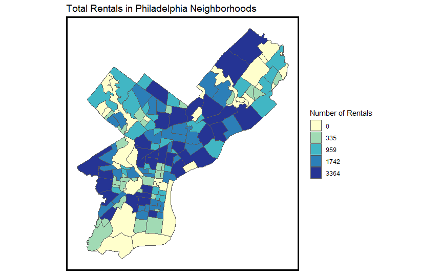

*Rentals by neighborhood in Philadelphia*

*Where are evictions in Philadelphia, and how has that changed over time?*

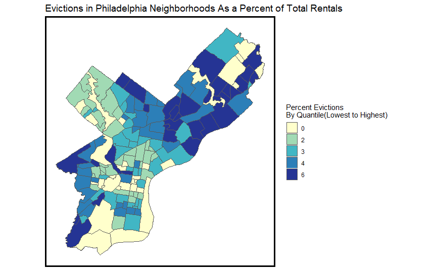

*Evictions by neighborhood in Philadelphia*

Between 2016 and 2018, there were about 55,700 evictions in the City. Understanding where legal evictions are occurring is beneficial for understanding the nature of the rental market in Philadelphia, which ultimately provides insights into illegal rentals.

The map below shows evictions by neighborhood between 2016-2018. Rather than showing a count of evictions, we instead chose to display evictions as a percentage in order to normalize the data and account for neighborhoods with higher or lower rental totals. As the map shows, evictions were concentrated in North and Northeast Philadelphia, as well as West Philadelphia. In general, these evictions were concentrated in lower-income, minority areas, which is consistent with findings from the report of homelessness produced by the mayor’s taskforce.

*Where are illegal rentals in Philadelphia, how has that changed over time, and what types of properties are being illegally rented?*

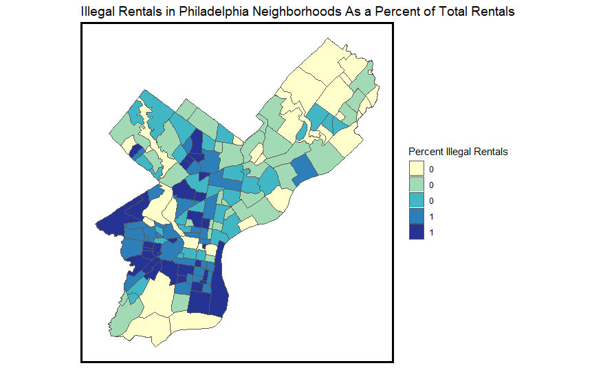

*Illegal rentals by neighborhood in Philadelphia*

Our exploratory analysis of illegal rentals in Philadelphia focused on several aspects of illegal rentals. Between 2010 and 2019, there were 7,428 citations given out by L&I inspectors to individuals renting their property illegally. This number indicates all of the illegal rentals the city is aware of, however, it is a proxy for illegal rentals. The real number of illegal rentals cannot be officially captured. The number of illegal rentals by year increased between 2016 and 2018. Of these citations, about 77 percent were for one and two family homes, 21 percent were multi-family units, and about 2 percent were for rooms in houses. This distribution is unsurprising given the distribution of housing typologies in Philadelphia. Because Philadelphia is a city of row-homes, not high-rises; it would make sense that there would be one and two family homes with illegal rental citations.

The map above shows illegal rentals by neighborhood as a percentage of total rentals by neighborhood. As the map shows, at the neighborhood level, illegal rentals comprise almost zero percent of total rentals, however, in some neighborhoods they comprise over one percent of rentals. Additionally, illegal rentals do not follow the same pattern as evictions. The highest neighborhood wide concentrations are in and around Center City and West Philadelphia, as opposed to the evictions we saw more in northern and eastern north Philadelphia.

Notably, the number of illegal rentals by year is very consistent. In 2016, there were 2,196 citations for illegal rentals. In 2017, there were 2,243 citations for illegal rentals, and in 2018, there were 2,337 citations for illegal rentals. While the number has gone up each year, the rate of change is minimal.

*3.2 Feature Engineering*  
OPA  
Aside from basing our base dataset off of OPA we also used housing characteristics variables to create a litany of engineers factor variables ranging from square footage to number of bathrooms. We also used OPA data to determine whether or not the property had an absentee landlord by creating variables based off of rows that had different mailing addresses and parcel addresses for tax mailing. Of these absentee landlords we also create variables based off of whether landlords were located in the greater Philly area (NJ or DE), or whether they were out-of-region. We created these variables based on the assumption that if a landlord is not physically present it would make it more difficult for them to maintain their paperwork and licensing in order.

Licenses  
We used the license information to create variables based on whether properties had been rented in this past. This meant we created variables that determined whether licenses were active or inactive, if they were inactive when had they expired, and how many licenses the specific parcel has had in the past. Together this shows us whether a property has been rented in the past, and if so, whether it is still rented, or has lapsed. In addition, we used K nearest neighbor to determine average distance of each property to its 5 nearest rental licenses.

Violations  
Our independent variable that we are predicting is the likelihood that a unit is being illegally rented. Arguably, whether the property has a past violation for illegally renting is thereby one of our most important values. Illegal rental violations are comprised of four different codes:

- 9-3902 (1) - 1 and 2 family homes
- 9-3902 (2) - multi-family homes
- 9-3902 (3) - rooming unit or house
- 9-3902 (4) - hotels

Additionally, from this dataset we were able to create variables that tell us:

- Length of time since last violation
- Number of violations at a home
- Kind of violation (interior/exterior)
- Violations status
- Average distance to five nearest violations (using K-nearest neighbor)

In creating these variables we are operating under the assumption that if a landlord is likely to receive one violation that this may be an indicator of other kinds of violations (in this case, illegal rentals).

Tax Delinquency  
The tax delinquency dataset required minimal feature engineering. The dataset already included a variable on the amount owed. We created one variable that calculated the number of years delinquent, and one binary variable set to 1 for all tax delinquent properties so that when joined back to the larger dataset we can easily identify the delinquent properties.

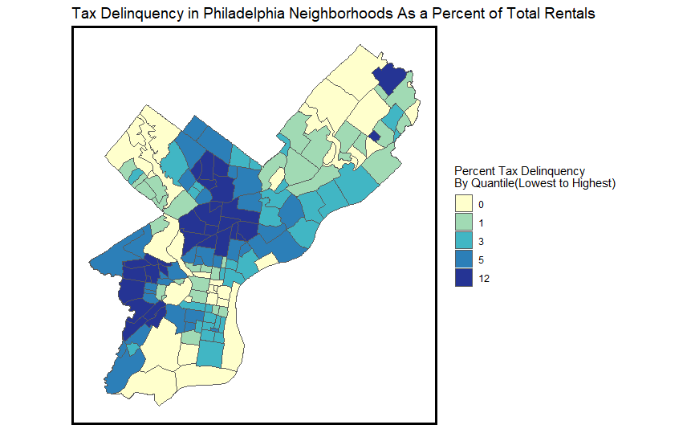

*Tax delinquency by neighborhood in Philadelphia*

There are approximately 25,000 tax delinquent parcels in Philadelphia. These homes are primarily located in central northern Philadelphia and west Philadelphia, accounting for up to twelve percent of parcels in some neighborhoods.

Census  
There is extensive research on who is disproportionately impacted by eviction. We wanted to see if these demographic characteristics were also linked to illegal rentals in Philadelphia. Because we could selected from the census which variables we wanted, minimal feature engineering was not required for this dataset.

Docket  
For the docket data, we wanted to determine, who are the repeat offenders and where are there properties evicting multiple families. In order to do this we aggregated evictions by landlord and by address in order to come up with a count. We then joined this data back to the original file so that every row has a landlord_evict_count and a property_evict_count.

*Which variables correlate with each other?*

To get a better understanding of the relationship between variables, we developed correlation matrices (corplots) for the three separate stories. Through the corplots, we are able to gain a better understanding of which independent variables are colinear, which is important for model building. The below corplot, for the geospatial model, shows that of the variables included, average distance to the five nearest rental licenses and average distance to the five nearest code violations are positively correlated with each other.

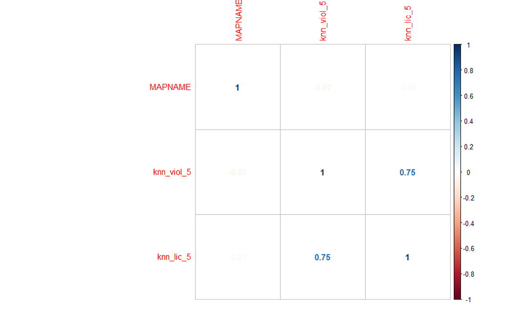

*Geospatial Model Corplot*

*How do variables compare between properties with and without an illegal rental violation?*  
In addition to corplots, to gain a better understanding of the characteristics of properties that have been rented illegally and properties that have not provides helps with building models. In instances where the characteristics of homes are different between the two categories, it is likely that these variables will be strong predictors in our models. Summary statistics for selected variables for two subsets of our data, where illegal rentals have occurred and where illegal rentals have not occured, are shown below.

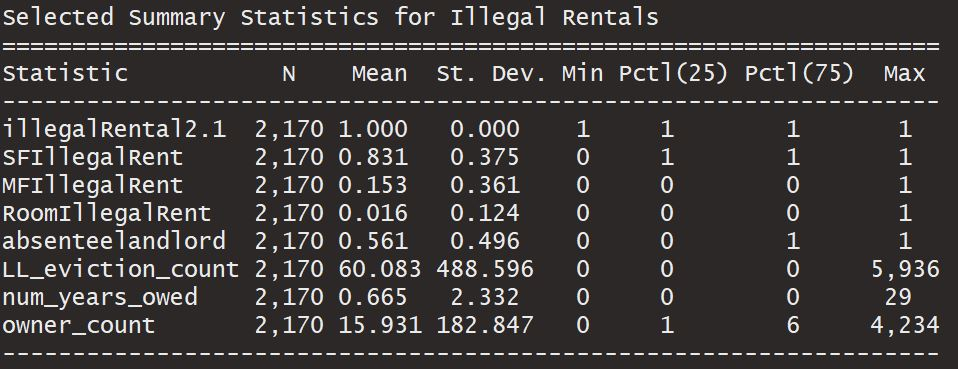

*Summary Statistics of Selected Variables (Illegal Rentals)*

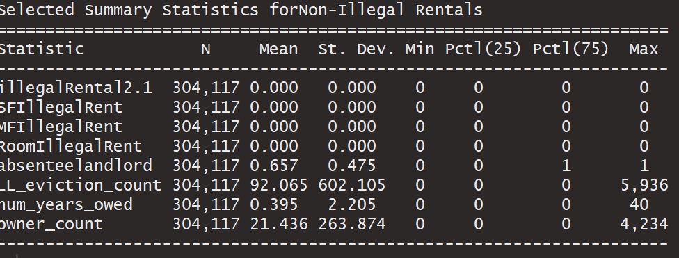

*Summary Statistics of Selected Variables (non-Illegal Rentals)*

As the tables shows, the count of evictions each landlord has had, the number of years a property is tax delinquent, and the number of code violations a property has received are all distributed differently across the two categories. Unsurprisingly, the mean landlord eviction count is greater in the subset of data where there has not been a citation for an illegal eviction. This is unsurprising given that eviction is a legal process only afforded to landlords who rent their properties legally. Conversely, the mean of number of years owed in taxes is higher in the illegal rental category. Surprisingly, the count of violations per property owner has a higher mean in the non-illegal rental category. While this does not indicate that there were not code violations in the illegal rental category, it indicates that property owners renting out their properties legally also have code violations, or have previously had a code violation.

*4.1 Model Building*  
We created three different models that will be ensembled, or joined, together to create one final model that will predict the likelihood that a residential rental property will be rented illegally, that is without a license. The three models were created include a:

- Housing model
- Geospatial model
- Demographic model

The housing model included data from the OPA dataset on housing characteristics, data on violations at the parcel level, data on rental licenses at the parcel level, and tax delinquency data at the parcel level. The geospatial model included only geospatial variables, and the demographic data from the census. For all three models, the dependent variable is a binary for ‘had illegal rental violation.’ We trained the models on a dataset that included confirmed illegal rentals. The models will ultimately be tested on the remainder of the dataset, which includes every additional residential rental property in Philadelphia, all of which are not confirmed to have been rented illegally.

*4.2 Validation*  
To validate our models, measured goodness of fit. This allowed us to compare predictions across several models, ultimately helping us determine which variables should be included in a final model for each story. This method can also be used in later iterations of visualize predictions across different classes. The below provides an example of how this validation was run.

```r
geo_fit1 <- glm(illegalRental2.1 ~ ., data = Finaldat_Geo %>%
                     dplyr::select(-knn_viol_5, -knn_lic_5, -MAPNAME),
                   family="binomial"(link="logit"))

testSetProbsgeo1 <-
  data.frame(class = geoTrain$illegalRental2.1,
             probs = predict(geo_fit1, geoTrain, type="response")) %>%
  mutate(predClass = as.factor(ifelse(probs >= 0.50 ,1,0)))

head(testSetProbsgeo1)
```

[output not shown]

At this stage, however, the predictions were not as expected, with the model predicting that every single property in the dataset has a 100 percent chance of being rented illegally. This indicates an issue with the dataset at large that must be resolved prior to any continuation of model building.

**5.0 Next Steps**  
After determining why our models are not running as anticipated, the next step in our model development is to improve the existing stories we have created through additional feature engineering and ensembling. We will also test out using random forest and XGBoost to improve the power of our model.

Importantly, we will also focus more on validation of our models. Validation measures we intend to examine include sensitive, specificity, AUC, and ROC. We also intend to conduct tests of spatial validation to determine if our model is both accurate and generalizable across the city. One way of doing such testing is to test the model by neighborhood and map the predictions or average error to see if there is any spatial variation in the accuracy of the predictions.

Down the road, we will also develop a wire-frame for a web-application that L&I inspectors will able able to use to better prioritize home inspections.

**Code Appendix**

```r
#scientific notation settings
options(scipen = 999)
options(dplyr.width = Inf)

#load library
library(KernSmooth)
library(raster)
library(tidyverse)
library(ModelMetrics)
library(caret)
library(plotROC)
library(knitr)
library(kableExtra)
library(grid)
library(gridExtra)
library(plotROC)
library(kableExtra)
library(sf)
library(ggplot2)
library(tigris)
library(QuantPsyc)
library(RSocrata)
library(viridis)
library(FNN)
library(dplyr)
library(stringr)
library(ggspatial)

#####Bases

#Philly base shapefile
phillyshape<-st_read('C:/Users/angel/Downloads/LARP741/TutorialData/PhiladelphiaBase/philadelphia.shp')

#Philly neighborhoods
phillyNeighborhoods <- st_read('C:/Users/angel/Downloads/phillyNeighborhoods/geo-data-master/Neighborhoods_Philadelphia/Neighborhoods_Philadelphia.shp')

#####Business licenses dataset (L&I Businesses)

#read shapefile
liBusiness<-st_read("C:/Users/angel/Downloads/MUSA801/li_business_licenses/li_business_licenses.shp")

##Active vs Inactive(/Expired/Closed/Revoked) Licenses
#Indicator variable for whether the property has a house inspection license
business<-liBusiness #make copy

#0=inactive/expired/closed/revoked ,1= active
business$ActiveInactive<-ifelse(business$licensesta=='Active','Active','Inactive, Expired, Closed, Revoked')
  #Active: 108683; Inactive:209674 (~51.8%)

##Rentals and Vacant Residential (rentals most likely include both commercial rentals and residential rentals)
#subset to only those that are rentals and vacant residential entries
business2 <- subset(business, business$licensetyp=='Rental' | business$licensetyp == 'Vacant Residential Property / Lot')
table(droplevels(business2$licensetyp))

#Among rentals and vacant residential only, check stats
table(business2$ActiveInactive)
  #Active: 87713; Inactive: 154783 (~56.6%)
table(droplevels(business2$licensetyp))
  #Rental 211706; Vacant Residential 30790
```

```r
#MAP
business2_sf <- st_as_sf(business2)

#Where are the Rentals and Vacant Residential Properties?
ggplot()+
  geom_sf(data=business2_sf[1:500,], aes(color=licensetyp), size=0.1)+
  ggtitle('Rental vs Vacant Residential Properties')+
  guides(fill=guide_legend(title=NULL))+
  theme(panel.background = element_blank())
```

```r
#Where are the Active and Inactive Licenses?
ggplot()+
  geom_sf(data=business2_sf[1:500,], aes(color=ActiveInactive), size=0.1)+
  ggtitle('Active vs Inactive Licenses')+
  guides(fill=guide_legend(title=NULL))+
  scale_color_manual(values=c('green','grey'))+
  theme(panel.background = element_blank())
```

```r
#####Code Violations dataset (L&I Violations)

#read csv file
liViolations<-read.csv("C:/Users/angel/Dropbox/MUSA801/Data/li_violations.csv")
#too big (1.3 mil); avoid running
#liViolationsShp<-st_read('C:/Users/angel/Downloads/MUSA801/li_violations/li_violations.shp')

#make copy of li_violations data
violationsCopy<-liViolations
sum(is.na(violationsCopy$violationtype)) #check for NA values - no empty rows

#filter using pipes by housing inspection violation
violations1<-violationsCopy
violations1<-
violations1 %>%
  filter(str_detect(violationtype,"^9-3902"))

violations2<-violationsCopy
violations2<-
  violations2%>%
  filter(violationtype == 'PM-102.6/3')

violations3<-violationsCopy
violations3<-
  violations3%>%
  filter(str_detect(violationtype,"^PM-102.1"))

violations4<-violationsCopy
violations4<-
  violations4%>%
  filter(violationtype == 'CP-101')

#combine housing inspection license failure dfs
#based on each violation number, total should be 28,139 rows
violationsTotal<-rbind(violations1,violations2,violations3,violations4)
#remove violations1,2,3,4

#all housing inspection failure violations (= the 4 violation codes provided by Jonathan in Piazza)
write.csv(violationsTotal,'kim_housInspFailViolations.csv')
```

```r
#Narrow down to violations related to illegal rentals:
# since valid rental license inspections occur on a reactive basis,
# it is assumed that these violations are given when illegal rentals occur
table(droplevels(violations1$violationtype))
  #(1) 5761 - one and two family
  #(2) 1527 - multifamily property
  #(3) 140  - rooming unit house
  #(4) 5    - hotel

#remove hotel (out of scope)
illegalRentals<-
  violations1 %>%
  filter(violations1$violationtype!='9-3902 (4)')
#check only (1)-(3) are left
table(droplevels(illegalRentals$violationtype))
  #(1) 77.6% (5761/7428)
  #(2) 20.6% (1527/7428)
  #(3) 2% (140/7428)
```

```r
#Where do Illegal Rentals Occur?
ggplot()+
  geom_sf(data=phillyshape)+
  geom_point(data=illegalRentals,aes(x=geocode_x, y=geocode_y,color=violationtype),size=0.1)+
  ggtitle('Where do Illegal Rentals Occur?')+
  scale_color_manual(labels=c("One and two family", "Multi family", "Rooming unit or house"),
                     values=c("lightcoral","seagreen2","lightskyblue"))+
  guides(colour = guide_legend(override.aes = list(size=5)))+
  theme(panel.background = element_blank(),
        legend.title=element_blank(),
        axis.title=element_blank(),
        axis.text=element_blank(),
        axis.ticks=element_blank())
```

```r
#illegal rentals over time (column: violation date)
illegalRentals2 <- illegalRentals #make copy

illegalRentals2$violationYear<-illegalRentals2$violationdate
illegalRentals2$violationYear<-as.numeric(substr(illegalRentals2$violationYear, 0,4))

#write csv of only housing license violations (violation code 9-3902*)
write.csv(illegalRentals2,'kim_illegalRentals.csv')

#2016 and earlier (2010-2015)
illegal16<-
  illegalRentals2%>%
  filter(illegalRentals2$violationYear == 2010 |
         illegalRentals2$violationYear == 2012 |
         illegalRentals2$violationYear == 2013 |
         illegalRentals2$violationYear == 2014 |
         illegalRentals2$violationYear == 2015 |
         illegalRentals2$violationYear == 2016 )
illegal16$violationYear<-2016 #changed all to 2016 for color consistency

mapIllegal16<-
ggplot()+
  geom_sf(data=phillyshape)+
  geom_point(data=illegal16,aes(x=geocode_x, y=geocode_y,color=violationYear),size=0.1)+
  scale_fill_manual(c('blue'))+
  ggtitle('2016 and Earlier')+
  guides(fill=guide_legend(title=NULL))+
  theme(panel.background = element_blank(),
        legend.position = 'none',
        axis.title=element_blank(),
        axis.text=element_blank(),
        axis.ticks=element_blank())
mapIllegal16

#2017
illegal17<-
  illegalRentals2%>%
  filter(illegalRentals2$violationYear == 2017)

mapIllegal17<-
  ggplot()+
  geom_sf(data=phillyshape)+
  geom_point(data=illegal17,aes(x=geocode_x, y=geocode_y,color=violationYear),size=0.1)+
  ggtitle('2017')+
  guides(fill=guide_legend(title=NULL))+
  theme(panel.background = element_blank(),
        legend.position = 'none',
        axis.title=element_blank(),
        axis.text=element_blank(),
        axis.ticks=element_blank())
mapIllegal17

#2018
illegal18<-
  illegalRentals2%>%
  filter(illegalRentals2$violationYear == 2018)

mapIllegal18<-
  ggplot()+
  geom_sf(data=phillyshape)+
  geom_point(data=illegal18,aes(x=geocode_x, y=geocode_y,color=violationYear),size=0.1)+
  ggtitle('2018')+
  guides(fill=guide_legend(title=NULL))+
  theme(panel.background = element_blank(),
        legend.position = 'none',
        axis.title=element_blank(),
        axis.text=element_blank(),
        axis.ticks=element_blank())
mapIllegal18

#2019
illegal19<-
  illegalRentals2%>%
  filter(illegalRentals2$violationYear == 2019)

mapIllegal19<-
  ggplot()+
  geom_sf(data=phillyshape)+
  geom_point(data=illegal19,aes(x=geocode_x, y=geocode_y,color=violationYear),size=0.1)+
  ggtitle('2019')+
  guides(fill=guide_legend(title=NULL))+
  theme(panel.background = element_blank(),
        legend.position = 'none',
        axis.title=element_blank(),
        axis.text=element_blank(),
        axis.ticks=element_blank())
mapIllegal19

#facetted maps for violations over time
illegalRentalsMap<-
grid.arrange(mapIllegal16,mapIllegal17,mapIllegal18,
             nrow=1,top=textGrob('Unlicensed Rental Violations Over Time',gp=gpar(fontsize=15,font=3)))
illegalRentalsMap
```

```r
##violations type by year

#2016 and earlier
mapIllegal16_type<-
  ggplot()+
  geom_sf(data=phillyshape)+
  geom_point(data=illegal16,aes(x=geocode_x, y=geocode_y,color=violationtype),size=0.1)+
  ggtitle('2016 and Earlier')+
  guides(fill=guide_legend(title=NULL))+
  theme(panel.background = element_blank(),
        legend.position = 'none',
        axis.title=element_blank(),
        axis.text=element_blank(),
        axis.ticks=element_blank())
mapIllegal16_type

#2017
mapIllegal17_type<-
  ggplot()+
  geom_sf(data=phillyshape)+
  geom_point(data=illegal17,aes(x=geocode_x, y=geocode_y,color=violationtype),size=0.1)+
  ggtitle('2017')+
  guides(fill=guide_legend(title=NULL))+
  theme(panel.background = element_blank(),
        legend.position = 'none',
        axis.title=element_blank(),
        axis.text=element_blank(),
        axis.ticks=element_blank())
mapIllegal17_type

#2018
mapIllegal18_type<-
  ggplot()+
  geom_sf(data=phillyshape)+
  geom_point(data=illegal18,aes(x=geocode_x, y=geocode_y,color=violationtype),size=0.1)+
  ggtitle('2018')+
  guides(fill=guide_legend(title=NULL), colour = guide_legend(override.aes = list(size=5)))+
  theme(panel.background = element_blank(),
        legend.position = 'none',
        axis.title=element_blank(),
        axis.text=element_blank(),
        axis.ticks=element_blank())
mapIllegal18_type

#2019
mapIllegal19_type<-
  ggplot()+
  geom_sf(data=phillyshape)+
  geom_point(data=illegal19,aes(x=geocode_x, y=geocode_y,color=violationtype),size=0.1)+
  ggtitle('2019')+
  scale_color_manual(name='test',
                     breaks=c("9-3902 (1)", "9-3902 (2)", "9-3902 (3)"),
                     labels=c("One and two family", "Multi family", "Rooming unit or house"),
                     values=c('#f8766d', '#68B846','#00b0f6'))+
  guides(colour = guide_legend(override.aes = list(size=5)))+
  theme(panel.background = element_blank(),
        axis.title=element_blank(),
        axis.text=element_blank(),
        axis.ticks=element_blank())
mapIllegal19_type

#facetted maps for violation types over time
illegalRentalsMap_type <-
  grid.arrange(mapIllegal16_type, mapIllegal17_type, mapIllegal18_type, nrow=1,
               top=textGrob('Rental Violations Types Over Time',gp=gpar(fontsize=15,font=3)))
illegalRentalsMap_type
```

```r
#Evictions

evictions<-st_read('C:/Users/angel/Downloads/evictions_clip/evictions_clip/evictions_clip.shp')
table(evictions$year)

evictions2<-evictions
evictions2 = evictions %>% st_set_crs(4326) %>% st_transform(3857)

evictions2<-evictions2[,-c(23:42)]

#How do the evictions vary over time?
#2016
evictions16<-
  evictions2%>%
  filter(evictions$year == 2016)

evictions16map<-
  ggplot()+
  geom_sf(data=phillyshape)+
  geom_sf(data=evictions16[1:500,], aes(color=year), size=0.1)+
  ggtitle('2016')+
  guides(fill=guide_legend(title=NULL))+
  theme(panel.background = element_blank(),
        legend.position = 'none',
        axis.title=element_blank(),
        axis.text=element_blank(),
        axis.ticks=element_blank())
evictions16map

#2017
evictions17<-
  evictions2%>%
  filter(evictions$year == 2017)

evictions17map<-
  ggplot()+
  geom_sf(data=phillyshape)+
  geom_sf(data=evictions17[1:500,], aes(color=year), size=0.1)+
  ggtitle('2017')+
  guides(fill=guide_legend(title=NULL))+
  theme(panel.background = element_blank(),
        legend.position = 'none',
        axis.title=element_blank(),
        axis.text=element_blank(),
        axis.ticks=element_blank())
evictions17map

#2018
evictions18<-
  evictions2%>%
  filter(evictions$year == 2018)

evictions18map<-
  ggplot()+
  geom_sf(data=phillyshape)+
  geom_sf(data=evictions18[1:500,], aes(color=year), size=0.1)+
  ggtitle('2018')+
  guides(fill=guide_legend(title=NULL))+
  theme(panel.background = element_blank(),
        legend.position = 'none',
        axis.title=element_blank(),
        axis.text=element_blank(),
        axis.ticks=element_blank())
evictions18map

#facetted maps for evictions over time
grid.arrange(evictions16map, evictions17map, evictions18map,nrow=1,
             top=textGrob('Evictions Over Time',gp=gpar(fontsize=15,font=3)))
```

```r
#####Property assessement dataset (OPA Public)
opaPublicO<-read.csv("C:/Users/angel/Downloads/MUSA801/opa_properties_public.csv")

##Proper data set up -- saved from last time (no need to run 161-164)
#opaPublic[] <- lapply(opaPublic, as.character)
#colnames(opaPublic) = opaPublic[1, ] # the first row will be the header
#opaPublic = opaPublic[-1, ] #removes the first row

opaPublic<-opaPublicO #make copy

#filter out non residential zones
opaPublicResZones <-
  opaPublic %>%
  filter (opaPublic$zoning %like% '^RM' |
            opaPublic$zoning %like% '^RSA'|
            opaPublic$zoning %like% '^RSD'|
            opaPublic$zoning %like% '^RTA')
table(droplevels(opaPublicResZones$zoning))

#filter out residential mixed use districts
opaPublicResZones<-
  opaPublicResZones%>%
  filter(!str_detect(zoning, 'RMX1')) %>%
  filter(!str_detect(zoning, 'RMX3'))
table(droplevels(opaPublicResZones$zoning))

#filter out non residential (mixed use and vacant land kept for now)
opaPublicResZones2<-
  opaPublicResZones %>%
  filter(opaPublicResZones$category_code_description != 'Commercial' &
           opaPublicResZones$category_code_description != 'Industrial' &
           opaPublicResZones$category_code_description != '')
table(droplevels(opaPublicResZones2$category_code_description))
#0.1% mixed use; 7.1% multi family; 84.4% single family; 8.4% vacant;

#write csv for now - cleaned to only residential codes and residential category descriptions
write.csv(opaPublicResZones2, 'kim_opaPulicResZones2.csv')
#Load and Clean OPA Dataset

#Create absentee landlord variable (defined as outside of Philadelphia)
sum(is.na(opaPublic$mailing_city_state))
opaPublic$absenteelandlord<-ifelse(opaPublic$mailing_city_state=="", 0, ifelse(opaPublic$mailing_city_state=="PHILADELPHIA PA", 0, ifelse(opaPublic$mailing_city_state=='PHILA PA', 0,1)))
names(opaPublic)
opaPublic$homesteadexempt<-ifelse(opaPublic$homestead_exemption==30000, 1,0)


#subet to rental and active
active_licenses<-subset(rental_licenses, rental_licenses$licensesta=="Active")
inactive_licenses<-subset(rental_licenses, rental_licenses$licensesta!="Active")

##Clean Evictions Data from the court docket

#Clean docket, get rid of anything that isn't address
docket_clean <- docket[ -c(2,3,7:14,16,17:21,23:90) ]

#aggregate by address in order to get top evictors and top evicted properties
address_count<-docket_clean%>%
 group_by(defendant_address)%>%
  summarize(eviction_count=n())

#aggregate by landlord
plaintiff_count<-docket_clean%>%
 group_by(plaintiff) %>%
 summarize(case_count = n())

#find mode for plaintiffs
most_common<-sort(table(plaintiffs$plaintiff), decreasing=T)
sort(table(plaintiffs$plaintiff_atty_name), decreasing=T)
as.data.frame.matrix(most_common)

mode(plaintiffs$plaintiff)

agg<-aggregate(plaintiffs,
                by = list(plaintiffs$plaintiff),
                FUN = mode)
print(agg)
#find mode for plaintiff attorneys

#join columns back to cleaned data
docket_clean_2<-merge(x = plaintiff_count, y = docket_clean, by = "plaintiff", all.y = TRUE, all.x=TRUE)

#right outer, return all rows from the right table, and any rows with matching keys from the left table.
docket_clean_3<-merge(x = address_count, y = docket_clean_2, by = "defendant_address", all.y = TRUE, all.x=TRUE)

#save to csv
write_csv(docket_clean_3, "docket_clean.csv")

#CLEAN PLAINTIFFS dataset
plaintiffs <- plaintiffs[ -c(2,3,36,37,42,43) ]

#####   LICENSES   #####
#read data
business<- st_read('li_business_licenses.shp')

#create ACTIVE / INACTIVE column
business$ActiveInactive <- ifelse(business$licensesta=='Active','Active','Inactive,Expired,Closed,Revoked')

#subset RENTALS / VACANT RESIDENTIALS / HIGH RISE
business2 <- subset(business, business$licensetyp == 'Rental' | business$licensetyp == 'Vacant Residential Property / Lot' | business$licensetyp == 'High Rise')

#make LAT and LNG coordinates from geometry
business2$lng <- st_coordinates(business2)[,1]
business2$lat <- st_coordinates(business2)[,2]

#check type
class(business2) #sf;data.frame
sort(names(business2))

class(business2$opaaccount) #factor
business2$opaaccount_Copy <- as.integer(as.character(business2$opaaccount))
class(business2$opaaccount_Copy) #integer

class(business2$fulladdres) #factor
business2$fulladdres_Copy <- as.character(business2$fulladdres)
class(business2$fulladdres_Copy) #character

class(business2) #sf; data.frame
business2_df <- as.data.frame(business2)
class(business2_df) #data.frame

table(droplevels(business2_df$licensetyp)) # 211,706 rentals; 30,790 vacant res; 740 high rise
table(business2_df$ActiveInactive)         # 88,020 active; 155,216 inactive (~64% inactive)
table(business2_df$legalentit)             # 86,059 company; 156884 individual

#feature engineering
#Number of previous licenses
business_temp <-
  business2_df %>%
  group_by(fulladdres) %>%
  summarise(num_prev_lic=n())

business2_df<- left_join(business2_df,business_temp, by='fulladdres')

#Active or inactive based on most recent license date
business3 <- business2_df
business3$mostrecent2<- as.Date(as.character(business3$mostrecent))
business3$status_mostrecent <- ifelse (business3$mostrecent2 < as.Date('2018-01-31'), 'inactive','active')

#Length of time since last license if most recent is inactive
business3$license_year <- format(as.Date(business3$mostrecent, format="%d/%m/%Y"),"%Y")

class(business3$license_year) #character
business3$license_year <- as.integer(business3$license_year)
class(business3$license_year) #integer

business3$time_since_last <- ifelse(business3$num_prev_lic == 1 & business3$status_mostrecent == 'active', "only one active",
                                ifelse (business3$num_prev_lic == 1 & business3$status_mostrecent == 'inactive', 2018-business3$license_year,
                                        ifelse(business3$num_prev_lic > 1 & business3$status_mostrecent == 'active', 'newlicense',
                                               ifelse(business3$num_prev_lic > 1 & business3$status_mostrecent == 'inactive', 2018-business3$license_year, 00000))))
```

```r
business3_noDup_mostrec <-
  business3 %>%
  group_by(opaaccount_Copy) %>%
  slice(which.max(as.Date(mostrecent2)))

#check for consistency
#temp<-subset(business3_noDup_mostrec,select=c('ActiveInactive','status_mostrecent'))
table(business3_noDup_mostrec$ActiveInactive)
table(business3_noDup_mostrec$status_mostrecent)

names(business3_noDup_mostrec)

business3_noDup_mostrec$activitystat<-ifelse(business3_noDup_mostrec$ActiveInactive=="Active",1,0)
business3_noDup_mostrec$activitystat<-as.factor(business3_noDup_mostrec$activitystat)
class(business3_noDup_mostrec$activitystat)

#clean columns again
license_final<-subset(business3_noDup_mostrec, select=-c(objectid,licensenum,revenuecod,censustrac,legalfirst,legallastn,business_n,
                                                         eclipse_ad,licensesta,fulladdres,zip,ActiveInactive))


#variable classes to change
class(license_final$num_prev_lic)
class(license_final$mostrecent2)
class(license_final$status_mostrecent)
class(license_final$license_year)
class(license_final$time_since_last)
class(license_final$numberofun)

license_final$status_mostrecent<-as.factor(license_final$status_mostrecent)
license_final$time_since_last<-as.factor(license_final$time_since_last)
license_final$numberofun<-as.factor(license_final$numberofun)

#fixed effect for unkown inactive date
license_final$ZZinactivedate<-ifelse(is.na(license_final$inactiveda), 1,0)



######OPA###########
#read data
opafull<-fread('opa_properties_public.csv', header=TRUE, sep=",", colClasses='numeric')
lapply(opafull, class)

table(opafull$zoning)

#clean dataset
#Clean OPA, only get zoning that begins with R
opa<-opafull %>%
  filter(str_detect(zoning, "^R"))

#check distribution of zoning types
table(droplevels(opa$zoning))

#remove most irrelevant columns first
names(opa)
opa <- subset(opa,select=-c(the_geom, beginning_point, census_tract, depth, the_geom_webmercator,
                            assessment_date,book_and_page,building_code_description,
                            category_code_description,geographic_ward,market_value_date,
                            year_built_estimate, objectid, cross_reference,date_exterior_condition, suffix, view_type,
                            street_direction, street_code, street_designation, state_code))

names(opa)

#explore empties and NA's for the remaining columns
#run same code replacing columns
sum(opa$lng=='')
sum(opa$exempt_land=='')
sum(opa$exterior_condition=='')
sum(opa$fireplaces=='')
sum(opa$garage_spaces=='')
sum(opa$market_value=='')
sum(opa$homestead_exemption=='')
sum(opa$taxable_building=='')
sum(opa$lat=='')
sum(opa$taxable_land=='')
sum(opa$garage_spaces=='')
sum(opa$interior_condition=='')
sum(opa$off_street_open=='')
sum(opa$quality_grade=='')

#explore empties and NA's for the remaining columns
#if [1]NA, check if there are any NA to see if column is completely full
sum(is.na(opa$lng))#29
sum(is.na(opa$exempt_land))##237
sum(is.na(opa$exterior_condition))#13269
sum(is.na(opa$fireplaces))#6
sum(is.na(opa$garage_spaces))#6
sum(is.na(opa$market_value))#237
sum(is.na(opa$homestead_exemption))#483
sum(is.na(opa$taxable_building))#237
sum(is.na(opa$lat))#29
sum(is.na(opa$taxable_land))#237
sum(is.na(opa$garage_spaces))#6
sum(is.na(opa$interior_condition))#13439
sum(is.na(opa$off_street_open))#35
sum(is.na(opa$quality_grade))#126181

#####   OPA FEATURE ENGINEERING
#####basements
table(opa$basements)
class(opa$basements) #factor

#USE THIS 'COPY' COLUMN FOR BAR GRAPH ANALYSIS
#fill empty strings with ZZ category
opa$basements_Copy <- opa$basements
opa$basements_Copy <- ifelse(opa$basements_Copy=='','ZZ',as.character(opa$basements_Copy))
table(opa$basements_Copy)
class(opa$basements_Copy) #character
#change column type back to factor
opa$basements_Copy<- as.factor(as.character(opa$basements_Copy))
table(opa$basements_Copy)
class(opa$basements_Copy) #now class is factor

#create dummy columns for basement variable
opa$basement0<-ifelse(opa$basements_Copy == "0", 1,0) #no basement
opa$basementA<-ifelse(opa$basements_Copy == "A", 1,0) #full finished
opa$basementB<-ifelse(opa$basements_Copy == "B", 1,0) #full semi finished
opa$basementC<-ifelse(opa$basements_Copy == "C", 1,0) #full unfinished
opa$basementD<-ifelse(opa$basements_Copy == "D", 1,0) #full unknown finish
opa$basementE<-ifelse(opa$basements_Copy == "E", 1,0) #partial finished
opa$basementF<-ifelse(opa$basements_Copy == "F", 1,0) #partial semi finished
opa$basementG<-ifelse(opa$basements_Copy == "G", 1,0) #partial unfinished
opa$basementH<-ifelse(opa$basements_Copy == "H", 1,0) #partial unknown finish
opa$basementI<-ifelse(opa$basements_Copy == "I", 1,0) #unknown size finished
opa$basementJ<-ifelse(opa$basements_Copy == "J", 1,0) #unknown size unfinished

#fixed effect dummy for unknown
opa$basement_unknown <-ifelse(opa$basements_Copy == "ZZ", 1,0) #unknown (NA)

#make columns back to factor
opa$basement0<- as.factor(as.character(opa$basement0))
opa$basementA<- as.factor(as.character(opa$basementA))
opa$basementB<- as.factor(as.character(opa$basementB))
opa$basementC<- as.factor(as.character(opa$basementC))
opa$basementD<- as.factor(as.character(opa$basementD))
opa$basementE<- as.factor(as.character(opa$basementE))
opa$basementF<- as.factor(as.character(opa$basementF))
opa$basementG<- as.factor(as.character(opa$basementG))
opa$basementH<- as.factor(as.character(opa$basementH))
opa$basementI<- as.factor(as.character(opa$basementI))
opa$basementJ<- as.factor(as.character(opa$basementJ))
opa$basement_unknown<- as.factor(as.character(opa$basement_unknown))

#####central_air
table(opa$central_air)
class(opa$central_air) #factor

#USE THIS 'COPY' COLUMN FOR BAR GRAPH ANALYSIS
#fill empty strings with ZZ category
opa$central_air_Copy <- opa$central_air
opa$central_air_Copy <- ifelse(opa$central_air_Copy=='','ZZ',as.character(opa$central_air_Copy))
opa$central_air_Copy <- ifelse(opa$central_air_Copy=='Y','Y',
                               ifelse(opa$central_air_Copy=='ZZ','ZZ','N'))
table(opa$central_air_Copy)
class(opa$central_air_Copy) #character
```

```r
#change column type back to factor
opa$central_air_Copy<- as.factor(as.character(opa$central_air_Copy))
table(opa$central_air_Copy)
class(opa$central_air_Copy) #now class is factor

#fixed effect dummy for unknown
opa$central_air_unknown <-ifelse(opa$central_air_Copy == "ZZ", 1,0) #unknown (NA)

#make columns back to factor
opa$central_air_unknown<- as.factor(as.character(opa$central_air_unknown))

#####exempt_building (1 exempt; 0 not exempt)
table(opa$exempt_building)
class(opa$exempt_building)

#USE THIS 'COPY' COLUMN FOR BAR GRAPH ANALYSIS
#fill NAs with ZZ category
opa$exempt_building_Copy <- opa$exempt_building
opa$exempt_building_Copy <- ifelse(is.na(opa$exempt_building_Copy),'ZZ',
                               ifelse(opa$exempt_building_Copy>0,1,0))
table(opa$exempt_building_Copy)
class(opa$exempt_building_Copy) #character

#change column type back to factor
opa$exempt_building_Copy<- as.factor(as.character(opa$exempt_building_Copy))
table(opa$exempt_building_Copy)
class(opa$exempt_building_Copy) #now class is factor

#fixed effect dummy for unknown
opa$exempt_building_unknown <-ifelse(opa$exempt_building_Copy == "ZZ", 1,0) #unknown (NA)
#make column back to factor
opa$exempt_building_unknown<- as.factor(as.character(opa$exempt_building_unknown))

#####exempt_land (1 exempt; 0 not exempt)
table(opa$exempt_land)
class(opa$exempt_land)

#USE THIS 'COPY' COLUMN FOR BAR GRAPH ANALYSIS
#fill NAs with ZZ category
opa$exempt_land_Copy <- opa$exempt_land
opa$exempt_land_Copy <- ifelse(is.na(opa$exempt_land_Copy),'ZZ',
                                   ifelse(opa$exempt_land_Copy>0,1,0))
table(opa$exempt_land_Copy)
class(opa$exempt_land_Copy) #character
#change column type back to factor
opa$exempt_land_Copy<- as.factor(as.character(opa$exempt_land_Copy))
table(opa$exempt_land_Copy)
class(opa$exempt_land_Copy) #now class is factor

#fixed effect dummy for unknown
opa$exempt_land_unknown <-ifelse(opa$exempt_land_Copy == "ZZ", 1,0) #unknown (NA)
#make column back to factor
opa$exempt_land_unknown<- as.factor(as.character(opa$exempt_land_unknown))

#####exterior_condition
table(opa$exterior_condition)
class(opa$exterior_condition) #integer

#USE THIS 'COPY' COLUMN FOR BAR GRAPH ANALYSIS
#fill empty strings with ZZ category
opa$exterior_condition_Copy <- opa$exterior_condition
opa$exterior_condition_Copy <- ifelse(is.na(opa$exterior_condition_Copy),'ZZ',
                                      as.character(opa$exterior_condition_Copy))
table(opa$exterior_condition_Copy)
class(opa$exterior_condition_Copy) #character
#change column type back to factor
opa$exterior_condition_Copy<- as.factor(as.character(opa$exterior_condition_Copy))
table(opa$exterior_condition_Copy)
class(opa$exterior_condition_Copy) #now class is factor

#create dummy columns for exterior_condition variable
opa$extcondition0<-ifelse(opa$exterior_condition_Copy == "0", 1,0) #not applicable
opa$extcondition1<-ifelse(opa$exterior_condition_Copy == "1", 1,0) #
opa$extcondition2<-ifelse(opa$exterior_condition_Copy == "2", 1,0) #newer construction
opa$extcondition3<-ifelse(opa$exterior_condition_Copy == "3", 1,0) #above average
opa$extcondition4<-ifelse(opa$exterior_condition_Copy == "4", 1,0) #average
opa$extcondition5<-ifelse(opa$exterior_condition_Copy == "5", 1,0) #below average
opa$extcondition6<-ifelse(opa$exterior_condition_Copy == "6", 1,0) #vacant
opa$extcondition7<-ifelse(opa$exterior_condition_Copy == "7", 1,0) #sealed/structurally compromised

#fixed effect dummy for unknown
opa$exterior_condition_unknown <-ifelse(opa$exterior_condition_Copy == "ZZ", 1,0) #unknown (NA)

#make columns back to factor
opa$extcondition0<- as.factor(as.character(opa$extcondition0))
opa$extcondition1<- as.factor(as.character(opa$extcondition1))
opa$extcondition2<- as.factor(as.character(opa$extcondition2))
opa$extcondition3<- as.factor(as.character(opa$extcondition3))
opa$extcondition4<- as.factor(as.character(opa$extcondition4))
opa$extcondition5<- as.factor(as.character(opa$extcondition5))
opa$extcondition6<- as.factor(as.character(opa$extcondition6))
opa$extcondition7<- as.factor(as.character(opa$extcondition7))
opa$exterior_condition_unknown<- as.factor(as.character(opa$exterior_condition_unknown))

#####fireplaces
table(opa$fireplaces)
class(opa$fireplaces)

#USE 'COPY' and 'YN' COLUMN FOR BAR GRAPH ANALYSIS
#fill empty strings with ZZ category - distribution of fireplaces
#fireplaces_Copy shows distribution of number of fireplaces
opa$fireplaces_Copy <- opa$fireplaces
opa$fireplaces_Copy <- ifelse(is.na(opa$fireplaces_Copy),'ZZ',
                              as.character(opa$fireplaces_Copy))

#fireplaces_yn shows whether there is a fireplace or not (assumes ZZ is no fireplace)
#1 yes fireplace; 0 no fireplace
opa$fireplaces_yn<-ifelse(opa$fireplaces_Copy == 0 | opa$fireplaces_Copy == 'ZZ', 0,1)

#fixed effect dummy for unknown
opa$fireplaces_unknown <-ifelse(opa$fireplaces_Copy == "ZZ", 1,0) #unknown (NA)

#check column class types
class(opa$fireplaces_Copy) #character
class(opa$fireplaces_yn)   #numeric
class(opa$fireplaces_unknown) #numeric

#change column type back to factor
opa$fireplaces_Copy<- as.factor(as.character(opa$fireplaces_Copy))
opa$fireplaces_yn<- as.factor(as.character(opa$fireplaces_yn))
opa$fireplaces_unknown<- as.factor(as.character(opa$fireplaces_unknown))

#####fuel
table(opa$fuel)
class(opa$fuel) #factor

#USE THIS 'COPY' COLUMN FOR BAR GRAPH ANALYSIS
#fill empty strings with ZZ category
opa$fuel_Copy <- opa$fuel
opa$fuel_Copy <- ifelse(opa$fuel_Copy=='','ZZ',as.character(opa$fuel_Copy))
table(opa$fuel_Copy)
class(opa$fuel_Copy) #character
#change column type back to factor
opa$fuel_Copy<- as.factor(as.character(opa$fuel_Copy))
table(opa$fuel_Copy)
class(opa$fuel_Copy) #now class is factor

#create dummy columns for fuel variable
opa$fuelA<-ifelse(opa$fuel_Copy == 'A', 1,0) #natural gas
opa$fuelB<-ifelse(opa$fuel_Copy == 'B', 1,0) #oil heat
opa$fuelC<-ifelse(opa$fuel_Copy == 'C', 1,0) #electric
opa$fuelD<-ifelse(opa$fuel_Copy == 'D', 1,0) #coal
opa$fuelE<-ifelse(opa$fuel_Copy == 'E', 1,0) #solar
opa$fuelF<-ifelse(opa$fuel_Copy == 'F', 1,0) #wood
opa$fuelG<-ifelse(opa$fuel_Copy == 'G', 1,0) #other
opa$fuelH<-ifelse(opa$fuel_Copy == 'H', 1,0) #none
```

```r
#fixed effect dummy for unknown
opa$fuel_unknown <-ifelse(opa$fuel_Copy == "ZZ", 1,0) #unknown (NA)

#make columns back to factor
opa$fuelA<- as.factor(as.character(opa$fuelA))
opa$fuelB<- as.factor(as.character(opa$fuelB))
opa$fuelC<- as.factor(as.character(opa$fuelC))
opa$fuelD<- as.factor(as.character(opa$fuelD))
opa$fuelE<- as.factor(as.character(opa$fuelE))
opa$fuelF<- as.factor(as.character(opa$fuelF))
opa$fuelG<- as.factor(as.character(opa$fuelG))
opa$fuelH<- as.factor(as.character(opa$fuelH))
opa$fuel_unknown<- as.factor(as.character(opa$fuel_unknown))

#####garage_spaces (YES OR NO)
table(opa$garage_spaces)
class(opa$garage_spaces)

#USE 'COPY' COLUMN FOR BAR GRAPH ANALYSIS
#fill empty strings with ZZ category - distribution of garage_spaces
opa$garage_spaces_Copy <- opa$garage_spaces
opa$garage_spaces_Copy <- ifelse(is.na(opa$garage_spaces_Copy),'ZZ',
                                 ifelse(opa$garage_spaces_Copy>0,1,0))
#1 yes garage; 0 no garage (assuming NA is no garage)
opa$garage_spaces_yn<-ifelse(opa$garage_spaces_Copy == 0 | opa$garage_spaces_Copy == 'ZZ', 0,1)

#fixed effect dummy for unknown
opa$garage_spaces_unknown <-ifelse(opa$garage_spaces_Copy == "ZZ", 1,0) #unknown (NA)

#check column class types
class(opa$garage_spaces_Copy) #character
class(opa$garage_spaces_yn)   #numeric
class(opa$garage_spaces_unknown) #numeric

#change column type back to factor
opa$garage_spaces_Copy<- as.factor(as.character(opa$garage_spaces_Copy))
opa$garage_spaces_yn<- as.factor(as.character(opa$garage_spaces_yn))
opa$garage_spaces_unknown<- as.factor(as.character(opa$garage_spaces_unknown))

#####garage_spaces (SUBCATEGORIES)
table(opa$garage_spaces)
class(opa$garage_spaces) #integer

#USE THIS 'COPY' COLUMN FOR BAR GRAPH ANALYSIS
#fill empty strings with 99999 category (integer)
opa$garage_spaces_Copy2 <- opa$garage_spaces
opa$garage_spaces_Copy2 <- ifelse(is.na(opa$garage_spaces_Copy2),99999,
                                  as.character(opa$garage_spaces_Copy2))
table(opa$garage_spaces_Copy2)
class(opa$garage_spaces_Copy2) #character

#create dummy columns for garage_spaces variable
opa$garagespace0<-ifelse(opa$garage_spaces_Copy2 == '0', 1,0)
opa$garagespace1<-ifelse(opa$garage_spaces_Copy2 == '1', 1,0)
opa$garagespace2<-ifelse(opa$garage_spaces_Copy2 == '2', 1,0)
opa$garagespace3<-ifelse(opa$garage_spaces_Copy2 == '3', 1,0)
opa$garagespace4plus<-ifelse(opa$garage_spaces_Copy2 >= '4', 1,0)
#dummy for unknown already made above

#change column type back to factor
opa$garagespace0<- as.factor(as.character(opa$garagespace0))
opa$garagespace1<- as.factor(as.character(opa$garagespace0))
opa$garagespace2<- as.factor(as.character(opa$garagespace0))
opa$garagespace3<- as.factor(as.character(opa$garagespace0))
opa$garagespace4plus<- as.factor(as.character(opa$garagespace0))

#####garage_type
table(opa$garage_type)
class(opa$garage_type) #factor

#USE THIS 'COPY' COLUMN FOR BAR GRAPH ANALYSIS
#fill empty strings with ZZ category
opa$garage_type_Copy <- opa$garage_type
opa$garage_type_Copy <- ifelse(opa$garage_type_Copy=='','ZZ',as.character(opa$garage_type_Copy))
table(opa$garage_type_Copy)
class(opa$garage_type_Copy) #character
#change column type back to factor
opa$garage_type_Copy<- as.factor(as.character(opa$garage_type_Copy))
table(opa$garage_type_Copy)
class(opa$garage_type_Copy) #now class is factor

#create dummy columns for garage_type variable
opa$garagetype0<-ifelse(opa$garage_type_Copy == "0", 1,0) #none
opa$garagetypeA<-ifelse(opa$garage_type_Copy == "A", 1,0) #basement/built-in
opa$garagetypeB<-ifelse(opa$garage_type_Copy == "B", 1,0) #attached
opa$garagetypeC<-ifelse(opa$garage_type_Copy == "C", 1,0) #detached
opa$garagetypeF<-ifelse(opa$garage_type_Copy == "F", 1,0) #converted
opa$garagetypeS<-ifelse(opa$garage_type_Copy == "S", 1,0) #self-park
opa$garagetypeT<-ifelse(opa$garage_type_Copy == "T", 1,0) #attendant
#fixed effect dummy for unknown
opa$garage_type_unknown <-ifelse(opa$garage_type_Copy == "ZZ", 1,0) #unknown (NA)

#make columns back to factor
opa$garagetype0<- as.factor(as.character(opa$garagetype0))
opa$garagetypeA<- as.factor(as.character(opa$garagetypeA))
opa$garagetypeB<- as.factor(as.character(opa$garagetypeB))
opa$garagetypeC<- as.factor(as.character(opa$garagetypeC))
opa$garagetypeF<- as.factor(as.character(opa$garagetypeF))
opa$garagetypeS<- as.factor(as.character(opa$garagetypeS))
opa$garagetypeT<- as.factor(as.character(opa$garagetypeT))
opa$garage_type_unknown<- as.factor(as.character(opa$garage_type_unknown))

#####general_construction (exterior finish)
table(opa$general_construction)
class(opa$general_construction) #factor

#USE THIS 'COPY' COLUMN FOR BAR GRAPH ANALYSIS
#fill empty strings with ZZ category
opa$general_construction_Copy <- opa$general_construction
opa$general_construction_Copy <- ifelse(opa$general_construction_Copy=='','ZZ',as.character(opa$general_construction_Copy))
table(opa$general_construction_Copy)
class(opa$general_construction_Copy) #character
#change column type back to factor
opa$general_construction_Copy<- as.factor(as.character(opa$general_construction_Copy))
table(opa$general_construction_Copy)
class(opa$general_construction_Copy) #now class is factor

#create dummy columns for general_construction variable
opa$construction0<-ifelse(opa$general_construction_Copy == "0", 1,0)
opa$constructionA<-ifelse(opa$general_construction_Copy == "A", 1,0) #common brick
opa$constructionB<-ifelse(opa$general_construction_Copy == "B", 1,0) #brick and siding
opa$constructionC<-ifelse(opa$general_construction_Copy == "C", 1,0) #frame and siding
opa$constructionD<-ifelse(opa$general_construction_Copy == "D", 1,0) #frame and shingle
opa$constructionE<-ifelse(opa$general_construction_Copy == "E", 1,0) #stone
opa$constructionF<-ifelse(opa$general_construction_Copy == "F", 1,0) #stucco/cement/
opa$constructionG<-ifelse(opa$general_construction_Copy == "G", 1,0) #other
opa$constructionH<-ifelse(opa$general_construction_Copy == "H", 1,0) #brick and stucco
opa$constructionI<-ifelse(opa$general_construction_Copy == "I", 1,0) #stucco and siding
opa$constructionJ<-ifelse(opa$general_construction_Copy == "J", 1,0) #stone and stucco
#fixed effect dummy for unknown
opa$general_construction_unknown <-ifelse(opa$general_construction_Copy == "ZZ", 1,0) #unknown (NA)
```

```r
#make columns back to factor
opa$construction0<- as.factor(as.character(opa$construction0))
opa$constructionA<- as.factor(as.character(opa$constructionA))
opa$constructionB<- as.factor(as.character(opa$constructionB))
opa$constructionC<- as.factor(as.character(opa$constructionC))
opa$constructionD<- as.factor(as.character(opa$constructionD))
opa$constructionE<- as.factor(as.character(opa$constructionE))
opa$constructionF<- as.factor(as.character(opa$constructionF))
opa$constructionG<- as.factor(as.character(opa$constructionG))
opa$constructionH<- as.factor(as.character(opa$constructionH))
opa$constructionI<- as.factor(as.character(opa$constructionI))
opa$constructionJ<- as.factor(as.character(opa$constructionJ))
opa$general_construction_unknown<- as.factor(as.character(opa$general_construction_unknown))

#####homestead_exemption
table(opa$homestead_exemption)
class(opa$homestead_exemption) #integer

#USE THIS 'COPY' COLUMN FOR BAR GRAPH ANALYSIS
#fill empty strings with ZZ category
opa$homestead_exemption_Copy <- opa$homestead_exemption
opa$homestead_exemption_Copy <- ifelse(is.na(opa$homestead_exemption_Copy),'ZZ',as.character(opa$homestead_exemption_Copy))
#0 no homestead exemption; 1 yes homestead exemption; ZZ unknown homestead exemption
opa$homestead_exemption_Copy <- ifelse(opa$homestead_exemption_Copy==0,0,
                               ifelse(opa$homestead_exemption_Copy=='ZZ','ZZ',1))
#0 or 1; assumes ZZ is 0
opa$homestead_exemption_yn <- ifelse(opa$homestead_exemption_Copy==1,1,0)
#fixed effect dummy for unknown
opa$homestead_exemption_unknown <-ifelse(opa$homestead_exemption_Copy == "ZZ", 1,0) #unknown (NA)

#change column type back to factor
class(opa$homestead_exemption_Copy) #character
class(opa$homestead_exemption_yn) #numeric
class(opa$homestead_exemption_unknown) #numeric

opa$homestead_exemption_Copy<- as.factor(as.character(opa$homestead_exemption_Copy))
opa$homestead_exemption_yn<- as.factor(as.character(opa$homestead_exemption_yn))
opa$homestead_exemption_unknown<- as.factor(as.character(opa$homestead_exemption_unknown))

#####interior condition
table(opa$interior_condition)
class(opa$interior_condition) #integer

#USE THIS 'COPY' COLUMN FOR BAR GRAPH ANALYSIS
#fill empty strings with ZZ category
opa$interior_condition_Copy <- opa$interior_condition
opa$interior_condition_Copy <- ifelse(is.na(opa$interior_condition_Copy),'ZZ',
                                      as.character(opa$interior_condition_Copy))
table(opa$interior_condition_Copy)
class(opa$interior_condition_Copy) #character
#change column type back to factor
opa$interior_condition_Copy<- as.factor(as.character(opa$interior_condition_Copy))
table(opa$interior_condition_Copy)
class(opa$interior_condition_Copy) #now class is factor

#make dummy variables for interior conditions
opa$interiocondition0<-ifelse(opa$interior_condition_Copy == "0", 1,0) #not applicable
opa$interiocondition1<-ifelse(opa$interior_condition_Copy == "1", 1,0) #
opa$interiocondition2<-ifelse(opa$interior_condition_Copy == "2", 1,0) #new/rehabbed
opa$interiocondition3<-ifelse(opa$interior_condition_Copy == "3", 1,0) #above average
opa$interiocondition4<-ifelse(opa$interior_condition_Copy == "4", 1,0) #average
opa$interiocondition5<-ifelse(opa$interior_condition_Copy == "5", 1,0) #below average
opa$interiocondition6<-ifelse(opa$interior_condition_Copy == "6", 1,0) #vacant
opa$interiocondition7<-ifelse(opa$interior_condition_Copy == "7", 1,0) #sealed
#fixed effect dummy for unknown
opa$interior_condition_unknown <-ifelse(opa$interior_condition_Copy == "ZZ", 1,0) #unknown (NA)

#change column type back to factor
opa$interiocondition0<- as.factor(as.character(opa$interiocondition0))
opa$interiocondition1<- as.factor(as.character(opa$interiocondition1))
opa$interiocondition2<- as.factor(as.character(opa$interiocondition2))
opa$interiocondition3<- as.factor(as.character(opa$interiocondition3))
opa$interiocondition4<- as.factor(as.character(opa$interiocondition4))
opa$interiocondition5<- as.factor(as.character(opa$interiocondition5))
opa$interiocondition6<- as.factor(as.character(opa$interiocondition6))
opa$interiocondition7<- as.factor(as.character(opa$interiocondition7))
opa$interior_condition_unknown<- as.factor(as.character(opa$interior_condition_unknown))

##year_built
table(opa$year_built)
class(opa$year_built)#factor
sum(opa$year_built=='')#2
opa$year_built_copy<-opa$year_built
opa$year_built_copy<-ifelse(opa$year_built=='', 'zz',as.character(opa$year_built_copy))
table(opa$year_built_copy)

opa$pre1900<-ifelse(opa$year_built_copy <= 1900, 1,0) #factor
opa$btw1900and1950<-ifelse(opa$year_built_copy > 1900 & opa$year_built_copy < 1950, 1,0) #factor
opa$post1950<-ifelse(opa$year_built_copy >= 1950, 1,0) #factor
class(opa$year_built)
class(opa$pre1900)

opa$year_built_unknown<-ifelse(opa$year_built_copy =='zz', 1,0)
table(opa$year_built_unknown)

#change to factors
opa$pre1900<-as.factor(opa$pre1900)
opa$btw1900and1950<-as.factor(opa$btw1900and1950)
opa$post1950<-as.factor(opa$post1950)
opa$year_built_unknown<-as.factor(opa$year_built_unknown)

##number_of_rooms
opa$number_of_rooms2<-as.factor(opa$number_of_rooms)
sum(opa$number_of_rooms2=='')#0
table(opa$number_of_rooms2)
class(opa$number_of_rooms2)#factor
opa$rooms0to2<-ifelse(opa$number_of_rooms2 == 0 | opa$number_of_rooms2 == 1 | opa$number_of_rooms2 == 2, 1,0)
opa$rooms3to5<-ifelse(opa$number_of_rooms2 == 3 | opa$number_of_rooms2 == 4 | opa$number_of_rooms2 == 5, 1,0)
opa$rooms6to8<-ifelse(opa$number_of_rooms2 == 6 | opa$number_of_rooms2 == 7 | opa$number_of_rooms2 == 8, 1,0)
opa$rooms9to11<-ifelse(opa$number_of_rooms2 == 9 | opa$number_of_rooms2 == 10 | opa$number_of_rooms2 == 11, 1,0)
class(opa$rooms0to2)
table(opa$rooms3to5)

sum(opa$number_of_rooms=='') ##no NAs/missing

#make binary into factor
opa$rooms0to2<-as.factor(opa$rooms0to2)
opa$rooms3to5<-as.factor(opa$roooms3to5)
opa$rooms6to8<-as.factor(opa$rooms6to8)
opa$rooms9to11<-as.factor(opa$rooms9to11)

##site type
table(opa$site_type)
sum(opa$site_type=='') ##61053
opa$site_type_copy<-opa$site_type
opa$site_type_copy<-ifelse(opa$site_type == '',"zz", as.character(opa$site_type_copy))
table(opa$site_type)
```

```r
opa$sitetypeA<-ifelse(opa$site_type == 'A', 1,0) #in block
opa$sitetypeB<-ifelse(opa$site_type == 'B', 1,0) #block corner
opa$sitetypeC<-ifelse(opa$site_type == 'C', 1,0) #broken by breezeway
opa$sitetypeD<-ifelse(opa$site_type == 'D', 1,0) #end dwelling
opa$sitetypeE<-ifelse(opa$site_type == 'E', 1,0) #behind frontage property
opa$sitetypeF<-ifelse(opa$site_type == 'F', 1,0) #land locked
opa$sitetypeG<-ifelse(opa$site_type == 'G', 1,0) #penthouse
opa$site_type_unknown <-ifelse(opa$site_type_copy == "zz", 1,0)
table(opa$site_type_unknown)

#check Class and make factors
class(opa$sitetypeA)
opa$sitetypeA<-as.factor(opa$sitetypeA)
opa$sitetypeB<-as.factor(opa$sitetypeA)
opa$sitetypeC<-as.factor(opa$sitetypeA)
opa$sitetypeD<-as.factor(opa$sitetypeA)
opa$sitetypeE<-as.factor(opa$sitetypeA)
opa$sitetypeF<-as.factor(opa$sitetypeA)
opa$sitetypeG<-as.factor(opa$sitetypeA)
opa$site_type_unknown<-as.factor(opa$site_type_unknown)
class(opa$sitetypeA)

##utility (related to general modernization or remodeling)
table(opa$utility)
sum(opa$utility=='')#128625
table(opa$utility_copy)
opa$utility_copy <- ifelse(opa$utility_copy=='','ZZ',as.character(opa$utility_copy))
table(opa$utility_copy)
class(opa$utility_copy) #character

#change column type back to factor
opa$utility_copy<- as.factor(as.character(opa$utility_copy))
table(opa$utilty_copy)
class(opa$utility_copy) #now class is factor

opa$utilityA<-ifelse(opa$utility == 'A', 1,0) #none
opa$utilityB<-ifelse(opa$utility == 'B', 1,0) #modernized (fixtures)
opa$utilityC<-ifelse(opa$utility == 'C', 1,0) #remodeled (design and floor plan)
opa$utilityD<-ifelse(opa$utility == 'D', 1,0) #modernized and remodeled
opa$utility0<-ifelse(opa$utility == '0', 1,0)
opa$utility_unknown <-ifelse(opa$utility_copy == "ZZ", 1,0)
table(opa$utility_unknown)

opa$utilityA<-as.factor(opa$sitetypeA)
opa$utilityB<-as.factor(opa$sitetypeA)
opa$utilityC<-as.factor(opa$sitetypeA)
opa$utilityD<-as.factor(opa$sitetypeA)
opa$utilityO<-as.factor(opa$sitetypeA)
opa$utility_unknown<-as.factor(opa$utility_unknown)
class(opa$utilityA)

##building code ####NEED TO WORK THROUGH THIS TO DETERMINE IF BINARIES ARE NECESSARY HERE ###WE DO NOT NEED BUILDING CODE
table(opa$building_code)

##house_extension ##no empty rows for this column
table(opa$house_extension)
opa$hadextension<-ifelse(opa$house_extension >'0', 1,0)
opa$hadextension<-as.factor(opa$hadextension)
class(opa$hadextension)

##number_stories
table(opa$number_stories)
sum(opa$number_stories=='') #0
opa$story1<-ifelse(opa$number_stories == "1", 1,0)
opa$story2<-ifelse(opa$number_stories == "2", 1,0)
opa$story3<-ifelse(opa$number_stories == "3", 1,0)
opa$story4plus<-ifelse(opa$number_stories >= "4", 1,0)

opa$story1<-as.factor(opa$story1)
opa$story2<-as.factor(opa$story2)
opa$story3<-as.factor(opa$story3)
opa$story4plus<-as.factor(opa$story4plus)
class(opa$story1)

############### KEEP AS NUMERIC DATA
table(opa$total_livable_area)
sum(opa$total_livable_area=='')#0

##type_heater
table(opa$type_heater)
sum(opa$type_heater=='')#7184
opa$type_heate_copy <- opa$type_heater
opa$type_heate_copy <- ifelse(opa$type_heate_copy=='','ZZ',as.character(opa$type_heate_copy))
table(opa$type_heate_copy)
class(opa$type_heate_copy) #character

#change column type back to factor
opa$type_heate_copy<- as.factor(as.character(opa$type_heate_copy))
table(opa$type_heate_copy)
class(opa$type_heate_copy) #now class is factor

opa$heater0<-ifelse(opa$type_heater == "0", 1,0) #none
opa$heaterA<-ifelse(opa$type_heater == "A", 1,0) #hot air (ducts)
opa$heaterB<-ifelse(opa$type_heater == "B", 1,0) #hot water (radiators/baseboards)
opa$heaterC<-ifelse(opa$type_heater == "C", 1,0) #electric baseboard
opa$heaterD<-ifelse(opa$type_heater == "D", 1,0) #heat pump (outside unit)
opa$heaterE<-ifelse(opa$type_heater == "E", 1,0) #other
opa$heaterG<-ifelse(opa$type_heater == "G", 1,0) #radiant
opa$heaterH<-ifelse(opa$type_heater == "H", 1,0) #undetermined
opa$heater_unknown<-ifelse(opa$type_heater == 'zz', 1,0) #unknown heater

class(opa$heater0)
opa$heater0<-as.factor(opa$heater0)
opa$heaterA<-as.factor(opa$heaterA)
opa$heaterB<-as.factor(opa$heaterB)
opa$heaterC<-as.factor(opa$heaterC)
opa$heaterD<-as.factor(opa$heaterD)
opa$heaterE<-as.factor(opa$heaterE)
opa$heaterG<-as.factor(opa$heaterG)
opa$heaterH<-as.factor(opa$heaterH)
opa$heater_unknown<-as.factor(opa$heater_unknown)
class(opa$heater0)

##number of bathrooms
table(opa$number_of_bathrooms)
sum(opa$number_of_bathrooms=='')#0
opa$bathrooms1<-ifelse(opa$number_of_bathrooms == '1', 1,0)
opa$bathrooms2to3<-ifelse(opa$number_of_bathrooms == '2' | opa$number_of_bathrooms == '3', 1,0)
opa$bathrooms4plus<-ifelse(opa$number_of_bathrooms >= '4', 1,0)
opa$bathroom_unknown<-ifelse(opa$number_of_bathrooms == '0', 1,0)

sum(opa$bathroom_unknown)

opa$bathrooms1<-as.factor(opa$bathrooms1)
opa$bathrooms2to3<-as.factor(opa$bathrooms2to3)
opa$bathrooms4plus<-as.factor(opa$bathrooms4plus)
opa$bathroom_unknown<-as.factor(opa$bathroom_unknown)
class(opa$bathrooms1)

##quality_grade
table(opa$quality_grade)
sum(opa$quality_grade=='')
sum(is.na(opa$quality_grade))#126181

#fill empty strings with ZZ category ####IS THIS NEEDED
opa$quality_grade_copy <- opa$quality_grade
opa$quality_grade_copy <- ifelse(opa$quality_grade_copy=='','ZZ',as.character(opa$quality_grade_copy))
table(opa$quality_grade_copy)
class(opa$quality_grade_copy) #character
#change column type back to factor
opa$quality_grade_copy<- as.factor(as.character(opa$quality_grade_copy))
table(opa$quality_grade_copy)
class(opa$quality_grade_copy) #now class is factor

opa$qualitygrade1<- ifelse(opa$quality_grade_copy == '1', 1,0) #low
opa$qualitygrade2<- ifelse(opa$quality_grade_copy == '2', 1,0) #below average
opa$qualitygrade3<- ifelse(opa$quality_grade_copy == '3', 1,0) #average
opa$qualitygrade4<- ifelse(opa$quality_grade_copy == '4', 1,0) #above average
opa$qualitygrade5<- ifelse(opa$quality_grade_copy == '5', 1,0) #superior
opa$qualitygrade6<- ifelse(opa$quality_grade_copy == '6', 1,0) #highest
opa$quality_grade_unknown<-ifelse(opa$quality_grade_copy == 'zz', 1,0) #unknown
```

```r
class(opa$qualitygrade1)

opa$qualitygrade1<-as.factor(opa$qualitygrade1)
opa$qualitygrade2<-as.factor(opa$qualitygrade2)
opa$qualitygrade3<-as.factor(opa$qualitygrade3)
opa$qualitygrade4<-as.factor(opa$qualitygrade4)
opa$qualitygrade5<-as.factor(opa$qualitygrade5)
opa$qualitygrade6<-as.factor(opa$qualitygrade6)
opa$quality_grade_unknown<-as.factor(opa$quality_grade_unknown)

class(opa$qualitygrade1)

##unfinished
table(opa$unfinished)
sum(opa$unfinished=='')
opa$unfinished_copy<-opa$unfinished
opa$unfinished_copy<-ifelse(opa$unfinished_copy=='', 'zz', as.character(opa$unfinished_copy))
table(opa$unfinished)

opa$isunfinished<-ifelse(opa$unfinished == "U", 1,0)
opa$isunfinished<-as.factor(opa$isunfinished)
class(opa$isunfinished)

##number_of_bedrooms
table(opa$number_of_bedrooms)
sum(opa$number_of_bedrooms=='')#0
opa$bedrooms0<-ifelse(opa$number_of_bedrooms == "0", 1,0)
opa$bedrooms1<-ifelse(opa$number_of_bedrooms == "1", 1,0)
opa$bedrooms2<-ifelse(opa$number_of_bedrooms == "2", 1,0)
opa$bedrooms3<-ifelse(opa$number_of_bedrooms == "3", 1,0)
opa$bedrooms4<-ifelse(opa$number_of_bedrooms == "4", 1,0)
opa$bedrooms5plus<-ifelse(opa$number_of_bedrooms >= "5", 1,0)

opa$bedrooms0<-as.factor(opa$bedrooms0)
opa$bedrooms1<-as.factor(opa$bedrooms1)
opa$bedrooms2<-as.factor(opa$bedrooms2)
opa$bedrooms3<-as.factor(opa$bedrooms3)
opa$bedrooms4<-as.factor(opa$bedrooms4)
opa$bedrooms5plus<-as.factor(opa$bedrooms5plus)
class(opa$bedrooms0)

##frontage ##do not break down for now - can be numeric
table(opa$frontage)
sum(opa$frontage=='')#0

##sewer (yes or no connection to city sewer)
table(opa$sewer)
sum(opa$sewer=='')
opa$seweraccess<-ifelse(opa$sewer == 'Y', 1,0)
opa$seweraccess<-ifelse(opa$seweraccess=='', 'zz', as.character(opa$seweraccess))
table(opa$seweraccess)

class(opa$seweraccess)
opa$seweraccess<-as.factor(opa$seweraccess)
class(opa$seweraccess)

#Create absentee landlord variable (defined as outside of Philadelphia)
sum(is.na(opa$mailing_city_state))
#0 owner is in city; 1 owner is not in city Philadelphia (absent landlord)
opa$absenteelandlord<-ifelse(str_detect(opa$mailing_city_state,"^PHILA"), 0,
                                           ifelse(str_detect(opa$mailing_city_state,"^PHILD"), 0,
                                                  ifelse(str_detect(opa$mailing_city_state,"^PHILK"), 0,1)))
table(opa$absenteelandlord)

#Homestead Exempt (0 not exempt; 1 is exempt - homeowners)
opa$homesteadexempt<-ifelse(opa$homestead_exemption==0, 0,1)
table(opa$homesteadexempt)

#further break down into people that are not in Pennsylvania or New Jersey
opa$outofstateLL<-ifelse(grepl("PA", opa$mailing_city_state), 0, ifelse(grepl("NJ", opa$mailing_city_state), 0, 1))
opa$outofPhillyLL<-ifelse(grepl("PHILA", opa$mailing_city_state), 0,1)

#make into factors
opa$outofstateLL<-as.factor(opa$outofstateLL)
opa$outofPhillyLL<-as.factor(opa$outofPhillyLL)
opa$homestead_exempt<-as.factor(opa$homestead_exempt)

##check names, clean out unnecessary columns, and create final dataset to be joined
names(opa)
class(opa$exterior_condition)

opa_final<-subset(opa, select=-c(building_code, category_code,off_street_open,other_building,parcel_shape, recording_date,
                                 topography, total_area, basements_Copy,central_air_Copy, exempt_building, exempt_land,exterior_condition,
                                 fireplaces, fireplaces_Copy, fuel, garage_spaces, garage_type, general_construction,interior_condition,
                                 site_type_copy, quality_grade_copy, quality_grade_unknown, qualitygrade6,
                                 qualitygrade5, qualitygrade4, qualitygrade3, qualitygrade2, qualitygrade1, quality_grade))

#ONLY RENTALS, NO HOMESTEAD EXEMPT, WENT FROM 515 to 303K
opa_final<-subset(opa_final, opa_final$homesteadexempt==0)
names(opa_final)
sum(is.na(opa_final))

#####   LI VIOLATIONS   #####
#import dataset
violations<-read.csv('li_violations (1).csv')

#limit violations to 2016/17/18
violations$year<-substring(violations$violationdate,1,4)
violations_clean<-subset(violations, violations$year=="2016" | violations$year=='2017' | violations$year=='2018')

#create binary for illegal rental -
#### 9-3902(1) = 1 and 2 family homes, 9-3902(2) = Multi-family homes, 9-3902(3) = rooming unit or house, 9-3902(4) = hotel
violations_clean$illegalRental <- ifelse(violations_clean$violationtype == '9-3902 (1)' | violations_clean$violationtype == '9-3902 (2)'|
                                           violations_clean$violationtype == '9-3902 (3)',1,0)

#create binary for single family illegal rentals
violations_clean$SFIllegalRent<-ifelse(violations_clean$violationtype == '9-3902 (1)', 1,0)

#create binary for multi-family illegal rentals
violations_clean$MFIllegalRent<-ifelse(violations_clean$violationtype == '9-3902 (2)', 1,0)

#create binary for rooming unit or house illegal rental
violations_clean$RoomIllegalRent<-ifelse(violations_clean$violationtype == '9-3902 (3)', 1,0)

#violation status
#table(violations_clean$status)
#table(violations_clean$casestatus)
violations_clean$issue_fixed<-ifelse(violations_clean$status=="COMPLIED",1, ifelse(violations_clean$status=="RESOLVE", 1,0))
violations_clean$active<-ifelse(violations_clean$casestatus=="CLOSED", 0, 1)

#Number of Previous Violations
violation_count<-violations_clean%>%
  group_by(opa_account_num)%>%
  summarize(viol_count=n())

violations_clean_join <- left_join(violations_clean,violation_count, by='opa_account_num')

#Landlord with previous violations
landlord_count<-violations_clean%>%
  group_by(ownername)%>%
  summarize(owner_count=n())
landlord_count <- landlord_count[-c(1), ]

violations_clean_join <- left_join(violations_clean_join,landlord_count, by='ownername')

#Type of violation
#table(violations_clean$violationdescription)
violations_clean_join$exterior<-ifelse(grepl("EXT", violations_clean_join$violationdescription), 1,0)
violations_clean_join$interior<-ifelse(grepl("INT", violations_clean_join$violationdescription), 1,0)
```

```r
#Length of time since last violation
violations_clean_join$now<-as.Date('2019-01-31')
violations_clean_join$violationsdate2<-as.Date(substring(violations_clean_join$violationdate,1,10))

violations_clean_join <-
  violations_clean_join %>%
  mutate(now2 = ymd(now),
         then2 = ymd(violationsdate2))

violations_clean_join$lentim_sincelast_viol <- violations_clean_join$now2-violations_clean_join$then2

#keep only unique opa
violations_clean_unique <-
  violations_clean_join %>%
  group_by(opa_account_num) %>%
  slice(which.max(as.Date(violationsdate2)))

names(violations_clean_unique)

#make binary for multiple units
#update status
violations_clean_unique$status2 <- sub("^$", "OPEN", violations_clean_unique$status)

violations_clean_unique$multipleunits<-ifelse(violations_clean_unique$unit=="",0,1)

##make binary for has had violation
violations_clean_unique$hadviolation<-ifelse(violations_clean_unique$viol_count >'0', 1,0)
sum(violations_clean_unique$hadviolation)

#remove unecessary columns
violations_final<-subset(violations_clean_unique, select=-c(the_geom, objectid, addresskey, zip,
                                  censustract, casenumber, aptype, the_geom_webmercator, apfailkey, casegroup,
                                  casepriority, geocode_x, geocode_y, now, now2, then2, violationsdate2,prioritydesc,
                                  caseresolutioncode,casestatus,status,unit))

#change class to right class
names(violations_final)

class(violations_final$status2)
class(violations_final$multipleunits)
class(violations_final$year)
class(violations_final$illegalRental)
class(violations_final$RoomIllegalRent)
class(violations_final$SFIllegalRent)
class(violations_final$MFIllegalRent)
class(violations_final$exterior)
class(violations_final$interior)
class(violations_final$hadviolation)

violations_final$year<-as.factor(violations_final$year)
violations_final$illegalRental<-as.factor(violations_final$illegalRental)
violations_final$illegalRental<-as.factor(violations_final$RoomIllegalRent)
violations_final$illegalRental<-as.factor(violations_final$SFIllegalRent)
violations_final$illegalRental<-as.factor(violations_final$MFIllegalRent)
violations_final$exterior<-as.factor(violations_final$exterior)
violations_final$interior<-as.factor(violations_final$interior)
violations_final$status2<-as.factor(violations_final$status2)
violations_final$hadviolation<-as.factor(violations_final$hadviolation)
violations_final$multipleunits<-as.factor(violations_final$multipleunits)
violations_final<- violations_final[!is.na(violations_final$opa_account_num), ]

#####   TAX DELINQUENCY   #####
tax_delinquency <- read.csv('tax_delinquency_clean.csv')
names(tax_delinquency)

#clean tax delinquency, remove columns that we don't need
tax_delinquency_clean<-subset(tax_delinquency,select=-c(index,objectid,zip_code,zip_4,co_owner,mailing_address,mailing_city,
                                                        mailing_state,mailing_zip))

names(tax_delinquency_clean)

#check class of columns
class(tax_delinquency_clean$owes)
class(tax_delinquency_clean$num_years_owed)
class(tax_delinquency_clean$total_due)
tax_delinquency_clean$owes<-as.factor(tax_delinquency_clean$owes)

#####   CENSUS DATA   #####
#read in census data
demos<-read.csv('censuscombined_2.csv')
names(demos)

#remove rows without population
demos <- filter(demos, tot_population != 0)

#clean to remove rows without geospatial component
#joined_clean<- joined_data[!is.na(joined_data$lng.x), ]
#joined_clean<- joined_data[!is.na(joined_data$lat.x), ]

#ensure classes match
lapply(demos,class)
demos$pct_asian<-as.numeric(demos$pct_asian)
demos$pct_white<-as.numeric(demos$pct_white)
demos$pct_black<-as.numeric(demos$pct_black)
demos$pct_AmIndian<-as.numeric(demos$pct_AmIndian)
demos$pct_nativeHawaiian<-as.numeric(demos$pct_nativeHawaiian)
demos$pct_other<-as.numeric(demos$pct_other)
demos$pct_mixedrace<-as.numeric(demos$pct_mixedrace)
demos$pct_notwhte<-as.numeric(demos$pct_notwhte)
demos$pct_foreignborn<-as.numeric(demos$pct_foreignborn)
demos$pct_naturalizedcitizen<-as.numeric(demos$pct_naturalizedcitizen)
demos$pct_noncitizen<-as.numeric(demos$pct_noncitizen)
demos$pct_pop_below<-as.numeric(demos$pct_pop_below)
demos$pct_female_hh<-as.numeric(demos$pct_female_hh)

#fixed effect for lead NAs
demos$ZZleadelev<-ifelse(is.na(demos$num_elevated), 1,0)

#rename census demos
names(demos)[1]<-"FIPS"



##################DOCKET############################

#join in docket data
phillyshape<-st_read('phillyproj2010.shp')
phillyshape = phillyshape%>%st_set_crs(4326)
st_transform(phillyshape, 4326)

evictionsshape<-st_read('evictions_clip.shp')
evictionsshape = evictionsshape%>%st_set_crs(4326)
st_transform(evictionsshape, 4326)
st_intersection(phillyshape, evictionsshape)

evictionsdf2<-read.csv('docket_clean (2).csv')
names(evictionsshape)
names(evictionsdf2)

#join evictions shape and docket by id
evictions_join<-left_join(evictionsshape,evictionsdf2, by = c("id"="id"))
names(evictions_join)
#CLEAN DOCKET DATA
evictions_clean<-subset(evictions_join, select=c(ARC_Addres, year.x,month.x,plaintiff.y,X,Y, eviction_count.y,
                                                 case_count))
evictions_clean<-as.data.frame((evictions_clean))

#rename counts
names(evictions_clean)[2]<-"evict_year"
names(evictions_clean)[3]<-"evict_month"
names(evictions_clean)[8]<-"LL_eviction_count"
names(evictions_clean)[7]<-"home_evict_count"
sum(is.na(evictions_clean$LL_eviction_count))
sum(is.na(evictions_clean$home_evict_count))

#filter to just evict_year
evictions_clean2<-(subset (evictions_clean, evictions_clean$evict_year== 2016 | evictions_clean$evict_year== 2017 | evictions_clean$evict_year== 2018))


#KNN violations and licenses
#KNN FUNCTION
nn_function <- function(measureFrom,measureTo,k) {

  nn <-
    get.knnx(measureTo, measureFrom, k)$nn.dist

  output <-
    as.data.frame(nn) %>%
    rownames_to_column(var = "thisPoint") %>%
    gather(points, point_distance, V1:ncol(.)) %>%
    arrange(as.numeric(thisPoint)) %>%
    group_by(thisPoint) %>%
    summarize(pointDistance = mean(point_distance)) %>%
    arrange(as.numeric(thisPoint)) %>%
    dplyr::select(-thisPoint)
```

```r
  return(output)
}

#KNN
#create clean sf without nas in geometry
#sum(is.na(license_final2$lng))
license_final2<- license_final[!is.na(license_final$lat), ]
license.sf<-st_as_sf(license_final2, coords=c('lng','lat'),crs=4326)

rentals_geo<-opa_final[!is.na(opa_final$lat), ]
names(rentals_geo)
sum(is.na(rentals_geo$lat))
rentals.sf<-st_as_sf(rentals_geo, coords=c('lng','lat'), crs=4326)

violations_geo<-violations_final[!is.na(violations_final$lat), ]
violations.sf<-st_as_sf(violations_geo, coords=c('lng','lat'), crs=4326)

#pull the coordinates
rentals.xy <-
  rentals.sf %>%
  cbind(.,st_coordinates(rentals.sf))  %>%
  st_set_geometry(NULL) %>%
  dplyr::select(X,Y) %>%
  as.matrix()

license.xy <-
  license.sf %>%
  cbind(.,st_coordinates(license.sf))  %>%
  st_set_geometry(NULL) %>%
  dplyr::select(X,Y) %>%
  as.matrix()

violations.xy <-
  violations.sf %>%
  cbind(.,st_coordinates(violations.sf))  %>%
  st_set_geometry(NULL) %>%
  dplyr::select(X,Y) %>%
  as.matrix()

#add KNN as columns
knn_licenses_5<-nn_function(rentals.xy,license.xy,5)
rentals_geo <- cbind(rentals_geo, knn_licenses_5)
names(rentals_geo)
names(rentals_geo)[180]<-"knn_lic_5"

knn_violations_5<-nn_function(rentals.xy,violations.xy,5)
rentals_geo<-cbind(rentals_geo, knn_violations_5)
names(rentals_geo)[181]<-"knn_viol_5"

names(rentals_geo)
head(pointDistance)
opa_final2<-as.data.frame(rentals_geo)

### JOIN #1: OPA AND BUSINESS ###
#rename columns so they match
names(opa_final2)
names(license_final)

join1 <- left_join(opa_final2,license_final, by = c("parcel_number"="opaaccount_Copy"))
names(join1)
sum(is.na(join1$num_prev_lic))
303592-177164

#check correct join
#join_opa_business %>%
 # dplyr::select(parcel_number_Copy,opaaccount) %>%
  #head()


#####   JOIN #2: OPA, BUSINESS +VIOLATIONS   #####
join2 <- left_join(join1,violations_final, by=c('parcel_number'='opa_account_num'))
names(join2)

sum(is.na(join2$viol_count))
303592-246100

#Join 3: OPA, BUSINESS, VIOLATIONS + Tax Delinquency
join3 <- left_join(join2, tax_delinquency_clean, by=c('parcel_number'='opa_number'))
sum(is.na(join3$owes))
303592-278889

sum(is.na(join3$lat.y))
names(join3)

#JOIN 4: OPA, BUSINESS, VIOLATIONS, TAX DELINQUENCY + Census Spatial
#spatial join joined_data to census tracts
census<-st_read('C:/Users/Fay/Desktop/GIS/Philly Shape Files/phillyproj2010.shp')%>% st_transform(crs=4326)
names(census)[12]<-"lat"
names(census)[13]<-"lng"
census_sf<-st_as_sf(census, coords=c('lng','lat'), crs=4326)
census_sf = census_sf%>% st_set_crs(4326)

head(census_sf$lat)
head(census_sf$lng)
head(census_sf$geometry)

join3_geo<- join3[!is.na(join3$lat.x), ]
join3_geo2<-st_as_sf(join3_geo, coords=c('lng.x','lat.x'), crs=4326)

head(join3$lat.x)
head(join3$lng.x)
head(join3_geo$geometry)

#match crs
st_crs(join3_geo2) == st_crs(census_sf)

#spatial join census to join3
join4<-st_join(join3_geo2, census_sf, join=st_within)
head(join4$FIPS)
head(join4$FIPS_1)
head(join4$Tract)
head(join4$Tract10)
head(join4$TRACTCE10)

#Join 5: Left Join with census
join5<-left_join(join4, demos, by="FIPS")
head(join5$pct_white)

#names(census_joined)
head(join5$pct_white)
sum(is.na(join5$FIPS))

#Join 6: BUSINESS, VIOLATIONS, TAX DELINQUENCY, CENSUS + Docket
names(join5)


#which( colnames(census_joined2)=="location_Copy" )
#match("location_Copy",names(census_joined2))

#names(census_joined2)[192]<-"ARC_Addres"
#class(census_joined2$ARC_Addres)
#class(evictionsdf$ARC_Addres)

#left join the evictions by address
join6<-left_join(join5, evictions_clean, by=c("location"="ARC_Addres"))
names(join6)
head(join6$pct_white)

#determine what FIPS and what lat/lons are full
sum(is.na(join6$geometry))
head(join6$geometry)
sum(is.na(join6$geometry.x))
head(join6$geometry.x)
sum(is.na(join6$geometry.y))
head(join6$geometry.y)

sum(is.na(join6$lat.y))
head(join6$lat.y)
sum(is.na(join6$lat.y.y))
head(join6$lat.y.y)
sum(is.na(join6$lat.x.x))
head(join6$lat.x.x)
sum(is.na(join6$X))

sum(is.na(join6$lng.y))
sum(is.na(join6$lng))
sum(is.na(join6$lon))
sum(is.na(join6$Y))

table(join6$cen_x)

#Join 7: OPA, BUSINESS, VIOLATIONS, TAX DELINQUENCY, CENSUS, DOCKET + Neighborhoods
#clean join6 to only geospatial
#join6$geometry2<-paste(join6_clean$geometry.x, join6_clean$geometry.y, sep=",")
#head(join6_clean$pct_white)
join6_geo<-st_as_sf(join6, coords=c('geometry.x'), crs=4326)

#join6_geo<join6_geo %>% st_set_crs(4326)

#Add in Philly neighbs shapefile
phillyneighbs<-st_read('Neighborhoods_Philadelphia.shp')
phillyneighbs = phillyneighbs%>% st_set_crs(4326)
st_transform(phillyneighbs, 4326)
join6_geo = join6_geo%>%st_set_crs(4326)
st_transform(join6_geo, 4326)

#spatial join points to shape files
join7<-st_join(join6_geo, phillyneighbs)
names(join7)
head(join7$pct_white)

###CLEAN JOIN 7 SHAPEFILE TO REMOVE ANY UNNECESSARY COLUMNS####
join7_clean<-subset(join7, select=-c(basements, central_air, frontage, house_extension, house_number, location,
                                     homestead_exemption,mailing_address_1,mailing_address_2,
                                     mailing_care_of,mailing_city_state,mailing_street,mailing_zip,owner_1,owner_2,
                                     registry_number,street_name,legalname,business_m,geocode_x, geocode_y, fulladdres_Copy,
                                     OBJECTID,STATEFP10, COUNTYFP10, TRACTCE10, GEOID10, NAME10, NAMELSAD10, MTFCC10, FUNCSTAT10,
                                     ALAND10, AWATER10, LOGRECNO, cen_x,cen_y,FIPS_1, geometry,
                                     geometry.y, Shape_Area,street_name, taxable_building, taxable_land, zip_code, street_add,legalentit,fulladdres_Copy,Shape_Leng))

head(join7_clean$pct_black)


######FINAL CLEANING#####
join7_clean<-read.csv('join7_clean_327.csv')

join7_clean$illegalRental2 <- ifelse(join7_clean$SFIllegalRent == 1 | join7_clean$MFIllegalRent == 1 |
                                       join7_clean$RoomIllegalRent == 1,1,0)

join7_clean$hasrentallicense<-ifelse(join7_clean$licensetyp == "RENTAL", 1,0)
join7_clean$hasrentallicense<-as.numeric(join7_clean$hasrentallicense)
```

```r
join7_clean2<-subset(join7_clean, select=-c(separate_utilities, sewer, plaintiff.y, ownername, organization,caseaddeddate, caseresolutiondate,violationdate,violationtype,
                                            violationdescription, mostrecentinsp, street_address, owner, unfinished, utility, unit, type_heater, site_type,
                                            mostrecent2, status_mostrecent, status2, lng.y, lat.y, licensetyp, mostrecent, inactiveda, numberofun, opaaccount,
                                            councildis, lng.x, address, lat.x.x, initialiss, num_prev_lic, lon, lat.y.y, license_year, year, evict_year, evict_month,
                                            Y, X, time_since_last, ZZinactivedate))

join7_clean3<- replace(join7_clean2, is.na(join7_clean2), 0)

join7_FINAL<-join7_clean3
write.csv(join7_FINAL, 'join7_FINAL.csv')
names(join7_FINAL)
lapply(join7_FINAL, class)



names(join7_FINAL)

Finaldat_Geo<-subset(join7_FINAL, select=c(parcel_number, illegalRental2.1,SFIllegalRent, NAME, LISTNAME,MAPNAME, knn_viol_5, knn_lic_5))

Finaldat_Census<-subset(join7_FINAL, select=c(parcel_number, illegalRental2.1, ZZleadelev, Tract, FIPS, Tract10, pct_white, pct_black, pct_AmIndian, pct_asian,
                                              pct_nativeHawaiian, pct_other, pct_mixedrace, pct_notwhte, pct_foreignborn, pct_naturalizedcitizen, pct_noncitizen, pct_pop_below,
                                              rent_burden, pct_female_hh, num_elevated, num_screened, per_elevated, ZZleadelev))

Finaldat_Housing<-subset(join7_FINAL, select=-c(NAME, LISTNAME,MAPNAME, ZZleadelev, Tract, FIPS, Tract10, pct_white, pct_black, pct_AmIndian, pct_asian,
                                                pct_nativeHawaiian, pct_other, pct_mixedrace, pct_notwhte, pct_foreignborn, pct_naturalizedcitizen, pct_noncitizen, pct_pop_below,
                                                rent_burden, pct_female_hh, num_elevated, num_screened, per_elevated, ZZleadelev))

#write.csv(Finaldat_Housing,'finaldat_Housing.csv')
#write.csv(Finaldat_Census, 'finaldat_Census.csv')
#write.csv(Finaldat_Geo, 'finaldat_geo.csv')

Finaldat_Housing<-read.csv('finaldat_Housing.csv')
Finaldat_Geo<-read.csv('finaldat_geo.csv')
Finaldat_Census<-read.csv('finaldat_Census.csv')

#########MAPPING####################

#maptheme
mapTheme <- function(base_size = 12) {
  theme(
    text = element_text( color = "black"),
    plot.title = element_text(size = 14,colour = "black"),
    plot.subtitle=element_text(face="italic"),
    plot.caption=element_text(hjust=0),
    axis.ticks = element_blank(),
    panel.background = element_blank(),axis.title = element_blank(),
    axis.text = element_blank(),
    axis.title.x = element_blank(),
    axis.title.y = element_blank(),
    panel.grid.minor = element_blank(),
    panel.border = element_rect(colour = "black", fill=NA, size=2)
  )
}
#subset
total_rentals<-subset(neighbs_points,neighbs_points$homesteadexempt==0)
illegal_rentals<-subset(neighbs_points, neighbs_points$illegalRental==1)
evictions<-subset(neighbs_points, neighbs_points$home_evict_count>=1)
tax_delinquent<-subset(neighbs_points, neighbs_points$owes==1)

#aggregate
illegalrental_count<-illegal_rentals%>%
  group_by(MAPNAME)%>%
  summarize(illegal_rent_count=n())

illegalrental_count2<-illegal_rentals%>%
  group_by(MAPNAME)%>%
  mutate(count_IR = 1) %>% #every IR takes on a value of one
  aggregate(., phillyneighbs, length) ##period means what's been piped in (the coords, and join them to the fishnet with the number of points per grid cell)



################CORRELATION PLOTS####################

#summary statistics of variables
#sum_stats_cleanJoin7<-stargazer(Finaldat_Housing, type="text", title = "Summary Statistics")
sum_stats_housing <- stargazer(Finaldat_Housing, type="text", title = "Housing Features Summary Statistics")
sum_stats_Geo <-stargazer(Finaldat_Geo, type='text', title = 'Geospatial Features Summary Statistics')
sum_stats_Demos<-stargazer(Finaldat_Census, type = 'text', title = "Demogrpahic Features Summary Statistics")

illegal<-subset(join7_FINAL, join7_FINAL$illegalRental2.1 == '1')
notilelgal<-subset(join7_FINAL, join7_FINAL$illegalRental2.1 =='0')

sum_stats_illegal<-subset(illegal, select = c(illegalRental2.1,SFIllegalRent, MFIllegalRent, RoomIllegalRent, absenteelandlord, LL_eviction_count, num_years_owed,owner_count ))
sum_stats_notillegal<-subset(notilelgal, select = c(illegalRental2.1,SFIllegalRent, MFIllegalRent, RoomIllegalRent, absenteelandlord, LL_eviction_count, num_years_owed,owner_count ))

sumstats_illegal_markdown<-stargazer(sum_stats_illegal, type = 'text', title= "Selected Summary Statistics for Illegal Rentals")
sumstats_notillegal_markdown<-stargazer(sum_stats_notillegal, type = 'text', title= "Selected Summary Statistics forNon-Illegal Rentals")

#correlation
#Housing
Finaldat_Housing_CP <- subset(Finaldat_Housing,select=-c(illegalRental2.1,Index, zoning, exempt_building_Copy, garage_spaces_Copy,general_construction_Copy,year_built_copy,type_heate_copy,unfinished_copy,exterior_condition_Copy,exempt_land_Copy, homestead_exemption_Copy, pct_rent_of_Inc, knn_lic_5, knn_viol_5, lat, lng.y.1, GEOID2, geometry.x, illegalRental2, hasrentallicense))
class(Finaldat_Housing_CP)
unlist(lapply(Finaldat_Housing_CP,class))
colSums(is.na(Finaldat_Housing_CP))
Finaldat_Housing_CP<-na.omit(Finaldat_Housing_CP)
Finaldat_Housing_CP$sale_date<-as.numeric(Finaldat_Housing_CP$sale_date)
Finaldat_Houisng_CP<-sapply(Finaldat_Housing_CP, as.numeric)
unlist(lapply(Finaldat_Housing_CP, class))

write.csv(Finaldat_Housing_CP, 'finaldat_corplot2.csv')
Finaldat_Housing_CP<-read.csv('finaldat_corplot2.csv')
unlist(lapply(Finaldat_Housing_CP,class))
Finaldat_Housing_CP<-data.matrix(Finaldat_Housing_CP, rownames.force = NA)

M <- cor(Finaldat_Housing_CP)
corrplot(M,method='number')

#Geo
Finaldat_geo_CP <- subset(Finaldat_Geo,select=c(MAPNAME, knn_viol_5, knn_lic_5))
class(Finaldat_geo_CP)
unlist(lapply(Finaldat_geo_CP,class))
colSums(is.na(Finaldat_geo_CP))
Finaldat_geo_CP<-na.omit(Finaldat_geo_CP)
Finaldat_geo_CP<-data.matrix(Finaldat_geo_CP, rownames.force = NA)
```

```r
#write.csv(Finaldat_Housing_CP, 'finaldat_corplot2.csv')
#Finaldat_Housing_CP<-read.csv('finaldat_corplot2.csv')

unlist(lapply(Finaldat_Housing_CP,class))


M2 <- cor(Finaldat_geo_CP)
corrplot(M2,method='number')


################################## MODELS
#####   KITCHEN SINK MODEL
### subset data into three different models

#create models

names(join7_FINAL)
sum(Finaldat_Housing$illegalRental2.1)
sum(join7_FINAL$illegalRental2.1)
table(join7_FINAL$illegalRental2.1)

housingTrain<-subset(Finaldat_Housing, Finaldat_Housing$illegalRental2.1 == '1')
sum(housingTrain$illegalRental2.1)


Hlogitmodel1<-glm(illegalRental2.1~ market_value+(as.numeric(sale_date))+sale_price+total_livable_area+year_built+basement0+basementA+basementB+basementC+basementD+basementE+basement_unknown+basementG+basementH+basementI+basementJ+
                    central_air_unknown+extcondition0+extcondition1+extcondition2+extcondition3+extcondition4+extcondition5+extcondition6+extcondition7+exterior_condition_unknown+fireplaces_yn+fireplaces_unknown
                    +fuelA+fuelB+fuelC+fuelD+fuelE+fuelF+fuelG+fuelH+fuel_unknown+garage_spaces_yn+garage_spaces_unknown+garagespace0+garagespace1+garagespace2+garagespace3+garagespace4plus+
                    garagetype0+garagetypeA+garagetypeB+garagetypeC+garagetypeF+garagetypeS+garagetypeT+garage_type_unknown+construction0+constructionA+
                    constructionB+constructionC+constructionD+constructionE+constructionF+constructionG+constructionH+constructionI+constructionJ+general_construction_unknown+
                    homestead_exemption_yn+homestead_exemption_unknown+interiocondition0+interiocondition1+interiocondition2+interiocondition3+interiocondition4+
                    interiocondition5+interiocondition6+interiocondition7+interior_condition_unknown+pre1900+btw1900and1950+post1950+year_built_unknown+number_of_rooms2+
                    rooms0to2+rooms3to5+rooms6to8+rooms9to11+sitetypeA+sitetypeB+sitetypeC+sitetypeD+sitetypeE+sitetypeF+sitetypeG+site_type_unknown+utilityA+utilityB+utilityC+utilityD+utility0+
                    utilityO+hadextension+story1+story2+story3+story4plus+type_heate_copy+heater0+heaterA+heaterB+heaterC+heaterD+heaterE+heaterG+heaterH+heater_unknown+bathrooms1+
                    bathrooms2to3+bathrooms4plus+bathroom_unknown+unfinished_copy+isunfinished+bedrooms0+bedrooms1+bedrooms2+bedrooms3+bedrooms4+bedrooms5plus+seweraccess+absenteelandlord+homesteadexempt+
                    outofstateLL+outofPhillyLL+activitystat+issue_fixed+active+viol_count+owner_count+exterior+interior+lentim_sincelast_viol+
                    multipleunits+hadviolation+total_due+num_years_owed+owes+home_evict_count+LL_eviction_count, data=housingTrain, family = binomial)



summary(Hlogitmodel1)
#predhmodel1<-predict(Hlogitmodel1, Finaldat_Geo)


Hlogitmodel2<-glm(illegalRental2.1~ total_livable_area+year_built+basement0+basementA+basementB+basementC+basementD+basementE+basement_unknown+basementG+basementH+basementI+basementJ+
                    central_air_unknown+extcondition0+extcondition1+extcondition2+extcondition3+extcondition4+extcondition5+extcondition6+extcondition7+exterior_condition_unknown+
                    homestead_exemption_yn+homestead_exemption_unknown+interiocondition0+interiocondition1+interiocondition2+interiocondition3+interiocondition4+
                    interiocondition5+interiocondition6+interiocondition7+interior_condition_unknown+pre1900+btw1900and1950+post1950+year_built_unknown+number_of_rooms2+
                    rooms0to2+rooms3to5+rooms6to8+rooms9to11+sitetypeA+sitetypeB+sitetypeC+sitetypeD+sitetypeE+sitetypeF+sitetypeG+site_type_unknown+utilityA+utilityB+utilityC+utilityD+utility0+
                    utilityO+hadextension+story1+story2+story3+story4plus+heater0+heaterA+heaterB+heaterC+heaterD+heaterE+heaterG+heaterH+heater_unknown+bathrooms1+
                    bathrooms2to3+bathrooms4plus+bathroom_unknown+unfinished_copy+isunfinished+bedrooms0+bedrooms1+bedrooms2+bedrooms3+bedrooms4+bedrooms5plus+seweraccess+absenteelandlord+homesteadexempt+
                    outofstateLL+outofPhillyLL+activitystat+issue_fixed+active+viol_count+owner_count+exterior+interior+lentim_sincelast_viol+
                    multipleunits+hadviolation+total_due+num_years_owed+owes+home_evict_count+LL_eviction_count, data=housingTrain, family = binomial)



summary(Hlogitmodel2)


Hlogitmodel3<-glm(illegalRental2.1~ total_livable_area+basement0+basementA+basementB+basementC+basementD+basementE+basement_unknown+basementG+basementH+basementI+basementJ+
                    central_air_unknown+extcondition0+extcondition1+extcondition2+extcondition3+extcondition4+extcondition5+extcondition6+extcondition7+exterior_condition_unknown+
                    interiocondition0+interiocondition1+interiocondition2+interiocondition3+interiocondition4+
                    interiocondition5+interiocondition6+interiocondition7+interior_condition_unknown+pre1900+btw1900and1950+post1950+year_built_unknown+number_of_rooms2+
                    rooms0to2+rooms3to5+rooms6to8+rooms9to11+sitetypeA+sitetypeB+sitetypeC+sitetypeD+sitetypeE+sitetypeF+sitetypeG+site_type_unknown+utilityA+utilityB+utilityC+utilityD+utility0+
                    utilityO+hadextension+story1+story2+story3+story4plus+heater0+heaterA+heaterB+heaterC+heaterD+heaterE+heaterG+heaterH+heater_unknown+bathrooms1+
                    bathrooms2to3+bathrooms4plus+bathroom_unknown+unfinished_copy+isunfinished+bedrooms0+bedrooms1+bedrooms2+bedrooms3+bedrooms4+bedrooms5plus+seweraccess+absenteelandlord+homesteadexempt+
                    outofstateLL+outofPhillyLL+activitystat+issue_fixed+active+viol_count+owner_count+exterior+interior+lentim_sincelast_viol+
                    multipleunits+hadviolation+total_due+num_years_owed+owes+home_evict_count+LL_eviction_count, data=housingTrain, family = binomial)



summary(Hlogitmodel3)

Hlogitmodel4<-glm(illegalRental2.1~ total_livable_area+basement0+basementA+basementB+basementC+basementD+basementE+basement_unknown+basementG+basementH+basementI+basementJ+
                    central_air_unknown+extcondition0+extcondition1+extcondition2+extcondition3+extcondition4+extcondition5+extcondition6+extcondition7+exterior_condition_unknown+
                    interiocondition0+interiocondition1+interiocondition2+interiocondition3+interiocondition4+
                    interiocondition5+interiocondition6+interiocondition7+interior_condition_unknown+pre1900+btw1900and1950+post1950+year_built_unknown+number_of_rooms2+
                    rooms0to2+rooms3to5+rooms6to8+rooms9to11+hadextension+story1+story2+story3+story4plus+heater0+heaterA+heaterB+heaterC+heaterD+heaterE+heaterG+heaterH+heater_unknown+bathrooms1+
                    bathrooms2to3+bathrooms4plus+bathroom_unknown+unfinished_copy+isunfinished+bedrooms0+bedrooms1+bedrooms2+bedrooms3+bedrooms4+bedrooms5plus+seweraccess+absenteelandlord+homesteadexempt+
                    outofstateLL+outofPhillyLL+activitystat+issue_fixed+active+viol_count+owner_count+exterior+interior+lentim_sincelast_viol+
                    multipleunits+hadviolation+total_due+num_years_owed+owes+home_evict_count+LL_eviction_count, data=housingTrain, family = binomial)
```

```r
summary(Hlogitmodel4)

Hlogitmodel5<-glm(illegalRental2.1~ total_livable_area+basement0+basementA+basementB+basementC+basementD+basementE+basement_unknown+basementG+basementH+basementI+basementJ+
                    central_air_unknown+extcondition0+extcondition1+extcondition2+extcondition3+extcondition4+extcondition5+extcondition6+extcondition7+exterior_condition_unknown+
                    interiocondition0+interiocondition1+interiocondition2+interiocondition3+interiocondition4+
                    interiocondition5+interiocondition6+interiocondition7+interior_condition_unknown+pre1900+btw1900and1950+post1950+year_built_unknown+number_of_rooms2+
                    rooms0to2+rooms3to5+rooms6to8+rooms9to11++story1+story2+story3+story4plus+heater0+heaterA+heaterB+heaterC+heaterD+heaterE+heaterG+heaterH+heater_unknown+bathrooms1+
                    bathrooms2to3+bathrooms4plus+bathroom_unknown+unfinished_copy+isunfinished+bedrooms0+bedrooms1+bedrooms2+bedrooms3+bedrooms4+bedrooms5plus+seweraccess+absenteelandlord+
                    outofstateLL+outofPhillyLL+activitystat+issue_fixed+active+viol_count+owner_count+exterior+interior+lentim_sincelast_viol+
                    multipleunits+hadviolation+total_due+num_years_owed+owes+home_evict_count+LL_eviction_count, data=housingTrain, family = binomial)



summary(Hlogitmodel5)

Hlogitmodel6<-glm(illegalRental2.1~ total_livable_area+basement0+basementA+basementB+basementC+basementD+basementE+basement_unknown+basementH+basementI+basementJ+
                    central_air_unknown+extcondition0+extcondition1+extcondition2+extcondition3+extcondition4+extcondition5+extcondition6+extcondition7+exterior_condition_unknown+
                    interiocondition2+interiocondition3+interiocondition4+
                    interiocondition5+interior_condition_unknown+pre1900+btw1900and1950+year_built_unknown+number_of_rooms2+
                    rooms0to2+rooms3to5+rooms6to8+rooms9to11++story1+story2+story3+story4plus+heater0+heaterA+heaterB+heaterC+heaterE+heaterG+heaterH+heater_unknown+bathrooms1+
                    bathrooms2to3+bathrooms4plus+bathroom_unknown+unfinished_copy+bedrooms0+bedrooms1+bedrooms2+bedrooms3+bedrooms4+bedrooms5plus+seweraccess+absenteelandlord+
                    outofstateLL+outofPhillyLL+activitystat+issue_fixed+active+viol_count+owner_count+exterior+interior+lentim_sincelast_viol+
                    multipleunits+hadviolation+total_due+num_years_owed+owes+home_evict_count+LL_eviction_count, data=housingTrain, family = binomial)



summary(Hlogitmodel6)


Hlogitmodel7<-glm(illegalRental2.1~ total_livable_area+basement0+basementA+basementB+basementC+basementD+basementE+basement_unknown+basementH+basementI+basementJ+
                    central_air_unknown+extcondition0+extcondition1+extcondition2+extcondition3+extcondition4+extcondition5+extcondition6+extcondition7+exterior_condition_unknown+
                    interiocondition2+interiocondition3+interiocondition4+
                    interiocondition5+interior_condition_unknown+pre1900+btw1900and1950+year_built_unknown+number_of_rooms2+
                    rooms0to2+rooms3to5+rooms6to8+rooms9to11++story1+story2+story3+story4plus+heater0+heaterA+heaterB+heaterC+heaterE+heaterG+heaterH+heater_unknown+bathrooms1+
                    bathrooms2to3+bathrooms4plus+bathroom_unknown+bedrooms0+bedrooms1+bedrooms2+bedrooms3+bedrooms4+bedrooms5plus+seweraccess+absenteelandlord+
                    outofstateLL+outofPhillyLL+activitystat+issue_fixed+active+viol_count+owner_count+exterior+interior+lentim_sincelast_viol+
                    multipleunits+hadviolation+total_due+num_years_owed+owes+home_evict_count+LL_eviction_count, data=housingTrain, family = binomial)



summary(Hlogitmodel7)

Hlogitmodel8<-glm(illegalRental2.1~ total_livable_area+basement0+basementA+basementB+basementC+basementD+basementE+basementH+basementI+basementJ+
                    extcondition0+extcondition1+extcondition2+extcondition3+extcondition4+extcondition5+extcondition6+extcondition7+
                    interiocondition2+interiocondition3+interiocondition4+
                    interiocondition5+pre1900+btw1900and1950+number_of_rooms2+
                    rooms0to2+rooms3to5+rooms6to8+rooms9to11++story1+story2+story3+story4plus+heater0+heaterA+heaterB+heaterC+heaterE+heaterG+heaterH+bathrooms1+
                    bathrooms2to3+bathrooms4plus+bedrooms0+bedrooms1+bedrooms2+bedrooms3+bedrooms4+bedrooms5plus+seweraccess+absenteelandlord+
                    outofstateLL+outofPhillyLL+activitystat+issue_fixed+active+viol_count+owner_count+exterior+interior+lentim_sincelast_viol+
                    multipleunits+hadviolation+total_due+num_years_owed+owes+home_evict_count+LL_eviction_count, data=housingTrain, family = binomial)



summary(Hlogitmodel8)

Hlogitmodel9<-glm(illegalRental2.1 ~ total_livable_area+basement0+basementA+basementB+basementC+basementD+basementE+basementH+basementI+basementJ+
                    extcondition0+extcondition1+extcondition2+extcondition3+extcondition4+extcondition5+extcondition6+extcondition7+
                    interiocondition2+interiocondition3+interiocondition4+
                    interiocondition5+pre1900+btw1900and1950+number_of_rooms2+
                    rooms0to2+rooms3to5+rooms6to8+rooms9to11++story1+story2+story3+story4plus+heater0+heaterA+heaterB+heaterC+heaterE+heaterG+heaterH+bathrooms1+
                    bathrooms2to3+bathrooms4plus+bedrooms0+bedrooms1+bedrooms2+bedrooms3+bedrooms4+bedrooms5plus+seweraccess+absenteelandlord+
                    outofstateLL+activitystat+issue_fixed+active+viol_count+owner_count+lentim_sincelast_viol+
                    multipleunits+hadviolation+total_due+num_years_owed+owes+home_evict_count+LL_eviction_count, data=housingTrain, family = binomial)



summary(Hlogitmodel9)

predhmodel1<-predict(Hlogitmodel9, Finaldat_Geo, type='response')

######GOODNESS OF FIT FOR HOUSING MODEL######



library(tidyverse)
library(caret)
install.packages('yardstick')
library(yardstick)
install.packages('Metrics')
library(Metrics)
```

```r
housing_fit1 <- glm(illegalRental2.1 ~ ., data = housingTrain %>%
                     dplyr::select(-total_livable_area,-basement0,-basementA,-basementB,-basementC,-basementD,-basementE,-basementH,-basementI,-basementJ,
                                   -extcondition0,-extcondition1,-extcondition2,-extcondition3,-extcondition4,-extcondition5,-extcondition6,-extcondition7,
                                   -interiocondition2,-interiocondition3,-interiocondition4, -interiocondition5,-pre1900,-btw1900and1950,-number_of_rooms2,
                                   -rooms0to2,-rooms3to5,-rooms6to8,-rooms9to11,-story1,-story2,-story3,-story4plus,-heater0,-heaterA,-heaterB,-heaterC,-heaterE,-heaterG,-heaterH,
                                   -bathrooms1,-bathrooms2to3,-bathrooms4plus,-bedrooms0,-bedrooms1,-bedrooms2,-bedrooms3,-bedrooms4,-bedrooms5plus,-seweraccess,-absenteelandlord,
                                   -outofstateLL,-outofPhillyLL,-activitystat,-issue_fixed,-active,-viol_count,-owner_count,-exterior,-interior,-lentim_sincelast_viol,
                                   -multipleunits,-hadviolation,-total_due,-num_years_owed,-owes,-home_evict_count,-LL_eviction_count),
                   family="binomial"(link="logit"))

HtestSetProbs1 <-
  data.frame(class = housingTrain$illegalRental2.1,
             probs = predict(housing_fit1, housingTrain, type="response")) %>%
  mutate(predClass = as.factor(ifelse(probs >= 0.50 ,1,0)))

head(HtestSetProbs1)


housing_fit2 <- glm(illegalRental2.1 ~ ., data = housingTrain %>%
                      dplyr::select(-total_livable_area,-year_built,-basement0,-basementA,-basementB,-basementC,-basementD,-basementE,-basement_unknown,-basementG,-basementH,-basementI,-basementJ,
                                      -central_air_unknown,-extcondition0,-extcondition1,-extcondition2,-extcondition3,-extcondition4,-extcondition5,-extcondition6,-extcondition7,-exterior_condition_unknown,
                                      -homestead_exemption_yn,-homestead_exemption_unknown,-interiocondition0,-interiocondition1,-interiocondition2,-interiocondition3,-interiocondition4,
                                      -interiocondition5,-interiocondition6,-interiocondition7,-interior_condition_unknown,-pre1900,-btw1900and1950,-post1950,-year_built_unknown,-number_of_rooms2,
                                      -rooms0to2,-rooms3to5,-rooms6to8,-rooms9to11,-sitetypeA,-sitetypeB,-sitetypeC,-sitetypeD,-sitetypeE,-sitetypeF,-sitetypeG,-site_type_unknown,-utilityA,-utilityB,-utilityC,-utilityD,-utility0,
                                      -utilityO,-hadextension,-story1,-story2,-story3,-story4plus,-heater0,-heaterA,-heaterB,-heaterC,-heaterD+heaterE,-heaterG+heaterH,-heater_unknown,-bathrooms1,
                                      -bathrooms2to3,-bathrooms4plus,-bathroom_unknown,-unfinished_copy,-isunfinished,-bedrooms0,,-bedrooms1,-bedrooms2,,-bedrooms3,-bedrooms4,,-bedrooms5plus,-seweraccess,-absenteelandlord,-homesteadexempt,
                                      -outofstateLL,-outofPhillyLL,-activitystat,-issue_fixed,-active,-viol_count,-owner_count,-exterior,-interior,-lentim_sincelast_viol+
                                      -multipleunits,-hadviolation,-total_due,-num_years_owed,-owes,-home_evict_count,-LL_eviction_count),
                    family="binomial"(link="logit"))

HtestSetProbs2 <-
  data.frame(class = housingTrain$illegalRental2.1,
             probs = predict(housing_fit2, housingTrain, type="response")) %>%
  mutate(predClass = as.factor(ifelse(probs >= 0.50 ,1,0)))

head(HtestSetProbs2)


housing_fit3 <- glm(illegalRental2.1 ~ ., data = housingTrain %>%
                      dplyr::select(-total_livable_area,-basement0,-basementA,-basementB,-basementC,-basementD,-basementE,-basementH,-basementI,-basementJ,
                                    -extcondition0,-extcondition1,-extcondition2,-extcondition3,-extcondition4,-extcondition5,-extcondition6,-extcondition7,
                                    -interiocondition2,-interiocondition3,-interiocondition4, -interiocondition5,-pre1900,-btw1900and1950,-number_of_rooms2,
                                    -rooms0to2,-rooms3to5,-rooms6to8,-rooms9to11,-story1,-story2,-story3,-story4plus,-heater0,-heaterA,-heaterB,-heaterC,-heaterE,-heaterG,-heaterH,
                                    -bathrooms1,-bathrooms2to3,-bathrooms4plus,-bedrooms0,-bedrooms1,-bedrooms2,-bedrooms3,-bedrooms4,-bedrooms5plus,-seweraccess,-absenteelandlord,
                                    -outofstateLL,-outofPhillyLL,-activitystat,-issue_fixed,-active,-viol_count,-owner_count,-exterior,-interior,-lentim_sincelast_viol,
                                    -multipleunits,-hadviolation,-total_due,-num_years_owed,-owes,-home_evict_count,-LL_eviction_count),
                    family="binomial"(link="logit"))

HtestSetProbs3 <-
  data.frame(class = housingTrain$illegalRental2.1,
             probs = predict(housing_fit3, housingTrain, type="response")) %>%
  mutate(predClass = as.factor(ifelse(probs >= 0.50 ,1,0)))

head(HtestSetProbs3)


housing_fit4 <- glm(illegalRental2.1 ~ ., data = housingTrain %>%
                      dplyr::select(-total_livable_area,-basement0,-basementA,-basementB,-basementC,-basementD,-basementE,-basementH,-basementI,-basementJ,
                                    -extcondition0,-extcondition1,-extcondition2,-extcondition3,-extcondition4,-extcondition5,-extcondition6,-extcondition7,
                                    -interiocondition2,-interiocondition3,-interiocondition4, -interiocondition5,-pre1900,-btw1900and1950,-number_of_rooms2,
                                    -rooms0to2,-rooms3to5,-rooms6to8,-rooms9to11,-story1,-story2,-story3,-story4plus,-heater0,-heaterA,-heaterB,-heaterC,-heaterE,-heaterG,-heaterH,
                                    -bathrooms1,-bathrooms2to3,-bathrooms4plus,-bedrooms0,-bedrooms1,-bedrooms2,-bedrooms3,-bedrooms4,-bedrooms5plus,-seweraccess,-absenteelandlord,
                                    -outofstateLL,-outofPhillyLL,-activitystat,-issue_fixed,-active,-viol_count,-owner_count,-exterior,-interior,-lentim_sincelast_viol,
                                    -multipleunits,-hadviolation,-total_due,-num_years_owed,-owes,-home_evict_count,-LL_eviction_count),
                    family="binomial"(link="logit"))
```

```r
HtestSetProbs4 <-
  data.frame(class = housingTrain$illegalRental2.1,
             probs = predict(housing_fit4, housingTrain, type="response")) %>%
  mutate(predClass = as.factor(ifelse(probs >= 0.50 ,1,0)))

head(HtestSetProbs4)


housing_fit4 <- glm(illegalRental2.1 ~ ., data = housingTrain %>%
                      dplyr::select(-total_livable_area,-basement0,-basementA,-basementB,-basementC,-basementD,-basementE,-basementH,-basementI,-basementJ,
                                    -extcondition0,-extcondition1,-extcondition2,-extcondition3,-extcondition4,-extcondition5,-extcondition6,-extcondition7,
                                    -interiocondition2,-interiocondition3,-interiocondition4, -interiocondition5,-pre1900,-btw1900and1950,-number_of_rooms2,
                                    -rooms0to2,-rooms3to5,-rooms6to8,-rooms9to11,-story1,-story2,-story3,-story4plus,-heater0,-heaterA,-heaterB,-heaterC,-heaterE,-heaterG,-heaterH,
                                    -bathrooms1,-bathrooms2to3,-bathrooms4plus,-bedrooms0,-bedrooms1,-bedrooms2,-bedrooms3,-bedrooms4,-bedrooms5plus,-seweraccess,-absenteelandlord,
                                    -outofstateLL,-outofPhillyLL,-activitystat,-issue_fixed,-active,-viol_count,-owner_count,-exterior,-interior,-lentim_sincelast_viol,
                                    -multipleunits,-hadviolation,-total_due,-num_years_owed,-owes,-home_evict_count,-LL_eviction_count),
                    family="binomial"(link="logit"))

HtestSetProbs4 <-
  data.frame(class = housingTrain$illegalRental2.1,
             probs = predict(housing_fit4, housingTrain, type="response")) %>%
  mutate(predClass = as.factor(ifelse(probs >= 0.50 ,1,0)))

head(HtestSetProbs4)


housing_fit5 <- glm(illegalRental2.1 ~ ., data = housingTrain %>%
                      dplyr::select(-total_livable_area,-basement0,-basementA,-basementB,-basementC,-basementD,-basementE,-basementH,-basementI,-basementJ,
                                    -extcondition0,-extcondition1,-extcondition2,-extcondition3,-extcondition4,-extcondition5,-extcondition6,-extcondition7,
                                    -interiocondition2,-interiocondition3,-interiocondition4, -interiocondition5,-pre1900,-btw1900and1950,-number_of_rooms2,
                                    -rooms0to2,-rooms3to5,-rooms6to8,-rooms9to11,-story1,-story2,-story3,-story4plus,-heater0,-heaterA,-heaterB,-heaterC,-heaterE,-heaterG,-heaterH,
                                    -bathrooms1,-bathrooms2to3,-bathrooms4plus,-bedrooms0,-bedrooms1,-bedrooms2,-bedrooms3,-bedrooms4,-bedrooms5plus,-seweraccess,-absenteelandlord,
                                    -outofstateLL,-outofPhillyLL,-activitystat,-issue_fixed,-active,-viol_count,-owner_count,-exterior,-interior,-lentim_sincelast_viol,
                                    -multipleunits,-hadviolation,-total_due,-num_years_owed,-owes,-home_evict_count,-LL_eviction_count),
                    family="binomial"(link="logit"))

HtestSetProbs5 <-
  data.frame(class = housingTrain$illegalRental2.1,
             probs = predict(housing_fit5, housingTrain, type="response")) %>%
  mutate(predClass = as.factor(ifelse(probs >= 0.50 ,1,0)))

head(HtestSetProbs5)


housing_fit6 <- glm(illegalRental2.1 ~ ., data = housingTrain %>%
                      dplyr::select(-total_livable_area,-basement0,-basementA,-basementB,-basementC,-basementD,-basementE,-basementH,-basementI,-basementJ,
                                    -extcondition0,-extcondition1,-extcondition2,-extcondition3,-extcondition4,-extcondition5,-extcondition6,-extcondition7,
                                    -interiocondition2,-interiocondition3,-interiocondition4, -interiocondition5,-pre1900,-btw1900and1950,-number_of_rooms2,
                                    -rooms0to2,-rooms3to5,-rooms6to8,-rooms9to11,-story1,-story2,-story3,-story4plus,-heater0,-heaterA,-heaterB,-heaterC,-heaterE,-heaterG,-heaterH,
                                    -bathrooms1,-bathrooms2to3,-bathrooms4plus,-bedrooms0,-bedrooms1,-bedrooms2,-bedrooms3,-bedrooms4,-bedrooms5plus,-seweraccess,-absenteelandlord,
                                    -outofstateLL,-outofPhillyLL,-activitystat,-issue_fixed,-active,-viol_count,-owner_count,-exterior,-interior,-lentim_sincelast_viol,
                                    -multipleunits,-hadviolation,-total_due,-num_years_owed,-owes,-home_evict_count,-LL_eviction_count),
                    family="binomial"(link="logit"))

HtestSetProbs6 <-
  data.frame(class = housingTrain$illegalRental2.1,
             probs = predict(housing_fit6, housingTrain, type="response")) %>%
  mutate(predClass = as.factor(ifelse(probs >= 0.50 ,1,0)))

head(HtestSetProbs6)


housing_fit7 <- glm(illegalRental2.1 ~ ., data = housingTrain %>%
                      dplyr::select(-total_livable_area,-basement0,-basementA,-basementB,-basementC,-basementD,-basementE,-basementH,-basementI,-basementJ,
                                    -extcondition0,-extcondition1,-extcondition2,-extcondition3,-extcondition4,-extcondition5,-extcondition6,-extcondition7,
                                    -interiocondition2,-interiocondition3,-interiocondition4, -interiocondition5,-pre1900,-btw1900and1950,-number_of_rooms2,
                                    -rooms0to2,-rooms3to5,-rooms6to8,-rooms9to11,-story1,-story2,-story3,-story4plus,-heater0,-heaterA,-heaterB,-heaterC,-heaterE,-heaterG,-heaterH,
                                    -bathrooms1,-bathrooms2to3,-bathrooms4plus,-bedrooms0,-bedrooms1,-bedrooms2,-bedrooms3,-bedrooms4,-bedrooms5plus,-seweraccess,-absenteelandlord,
                                    -outofstateLL,-outofPhillyLL,-activitystat,-issue_fixed,-active,-viol_count,-owner_count,-exterior,-interior,-lentim_sincelast_viol,
                                    -multipleunits,-hadviolation,-total_due,-num_years_owed,-owes,-home_evict_count,-LL_eviction_count),
                    family="binomial"(link="logit"))

HtestSetProbs7 <-
  data.frame(class = housingTrain$illegalRental2.1,
             probs = predict(housing_fit7, housingTrain, type="response")) %>%
  mutate(predClass = as.factor(ifelse(probs >= 0.50 ,1,0)))
```

```r
head(HtestSetProbs7)


housing_fit8 <- glm(illegalRental2.1 ~ ., data = housingTrain %>%
                      dplyr::select(-total_livable_area,-basement0,-basementA,-basementB,-basementC,-basementD,-basementE,-basementH,-basementI,-basementJ,
                                    -extcondition0,-extcondition1,-extcondition2,-extcondition3,-extcondition4,-extcondition5,-extcondition6,-extcondition7,
                                    -interiocondition2,-interiocondition3,-interiocondition4, -interiocondition5,-pre1900,-btw1900and1950,-number_of_rooms2,
                                    -rooms0to2,-rooms3to5,-rooms6to8,-rooms9to11,-story1,-story2,-story3,-story4plus,-heater0,-heaterA,-heaterB,-heaterC,-heaterE,-heaterG,-heaterH,
                                    -bathrooms1,-bathrooms2to3,-bathrooms4plus,-bedrooms0,-bedrooms1,-bedrooms2,-bedrooms3,-bedrooms4,-bedrooms5plus,-seweraccess,-absenteelandlord,
                                    -outofstateLL,-outofPhillyLL,-activitystat,-issue_fixed,-active,-viol_count,-owner_count,-exterior,-interior,-lentim_sincelast_viol,
                                    -multipleunits,-hadviolation,-total_due,-num_years_owed,-owes,-home_evict_count,-LL_eviction_count),
                    family="binomial"(link="logit"))

HtestSetProbs8 <-
  data.frame(class = housingTrain$illegalRental2.1,
             probs = predict(housing_fit8, housingTrain, type="response")) %>%
  mutate(predClass = as.factor(ifelse(probs >= 0.50 ,1,0)))

head(HtestSetProbs8)


housing_fit9 <- glm(illegalRental2.1 ~ ., data = housingTrain %>%
                      dplyr::select(-total_livable_area,-basement0,-basementA,-basementB,-basementC,-basementD,-basementE,-basementH,-basementI,-basementJ,
                                    -extcondition0,-extcondition1,-extcondition2,-extcondition3,-extcondition4,-extcondition5,-extcondition6,-extcondition7,
                                    -interiocondition2,-interiocondition3,-interiocondition4, -interiocondition5,-pre1900,-btw1900and1950,-number_of_rooms2,
                                    -rooms0to2,-rooms3to5,-rooms6to8,-rooms9to11,-story1,-story2,-story3,-story4plus,-heater0,-heaterA,-heaterB,-heaterC,-heaterE,-heaterG,-heaterH,
                                    -bathrooms1,-bathrooms2to3,-bathrooms4plus,-bedrooms0,-bedrooms1,-bedrooms2,-bedrooms3,-bedrooms4,-bedrooms5plus,-seweraccess,-absenteelandlord,
                                    -outofstateLL,-outofPhillyLL,-activitystat,-issue_fixed,-active,-viol_count,-owner_count,-exterior,-interior,-lentim_sincelast_viol,
                                    -multipleunits,-hadviolation,-total_due,-num_years_owed,-owes,-home_evict_count,-LL_eviction_count),
                    family="binomial"(link="logit"))

HtestSetProbs9 <-
  data.frame(class = housingTrain$illegalRental2.1,
             probs = predict(housing_fit9, housingTrain, type="response")) %>%
  mutate(predClass = as.factor(ifelse(probs >= 0.50 ,1,0)))

head(HtestSetProbs9)

#housingTrain2<-
#mutate(housingTrain, illegalRental3 = ifelse(illegalRental2.1 ==1, "IllegalRental", "NoIllegalRental"))

#housingTrain2 <- as.matrix(housingTrain2)
#lapply(housingTrain2, class)
#housingTrain2$housingTrain2<-as.numeric(housingTrain2$housingTrain2)
#lapply(housingTrain2, class)

#ctrl<-trainControl(method = 'cv', number=100, classProbs=T, summaryFunction=twoClassSummary)

#cvFIT<-train(housingTrain2 ~ ., data = housingTrain2 %>%
 #              dplyr::select(-total_livable_area,-basement0,-basementA,-basementB,-basementC,-basementD,-basementE,-basementH,-basementI,-basementJ,
#                             -extcondition0,-extcondition1,-extcondition2,-extcondition3,-extcondition4,-extcondition5,-extcondition6,-extcondition7,
#                             -interiocondition2,-interiocondition3,-interiocondition4, -interiocondition5,-pre1900,-btw1900and1950,-number_of_rooms2,
#                             -rooms0to2,-rooms3to5,-rooms6to8,-rooms9to11,-story1,-story2,-story3,-story4plus,-heater0,-heaterA,-heaterB,-heaterC,-heaterE,-heaterG,-heaterH,
#                             -bathrooms1,-bathrooms2to3,-bathrooms4plus,-bedrooms0,-bedrooms1,-bedrooms2,-bedrooms3,-bedrooms4,-bedrooms5plus,-seweraccess,-absenteelandlord,
#                             -outofstateLL,-outofPhillyLL,-activitystat,-issue_fixed,-active,-viol_count,-owner_count,-exterior,-interior,-lentim_sincelast_viol,
#                             -multipleunits,-hadviolation,-total_due,-num_years_owed,-owes,-home_evict_count,-LL_eviction_count),
#             method='glm', family='binomial',
#             metric='ROC',
#             na.action=na.omit,
#             trControl=ctrl)


#cvFit

#####GEO MODEL#####
geoTrain<-subset(Finaldat_Geo, Finaldat_Geo$illegalRental2.1=='1')
names(geoTrain)
geologitmodel1<-glm(illegalRental2.1~knn_viol_5+knn_lic_5 + MAPNAME, data=geoTrain, family=binomial)
summary(geologitmodel1)

geologitmodel2<-glm(illegalRental2.1~knn_viol_5+knn_lic_5, data=geoTrain, family=binomial)
summary(geologitmodel2)

geologitmodel3<-glm(illegalRental2.1~as.factor(MAPNAME), data=geoTrain, family=binomial)
summary(geologitmodel3)

geologitmodel4<-glm(illegalRental2.1~knn_viol_5+knn_lic_5+as.factor(MAPNAME), data=geoTrain, family=binomial)
summary(geologitmodel4)

###validation

geo_fit1 <- glm(illegalRental2.1 ~ ., data = Finaldat_Geo %>%
                     dplyr::select(-knn_viol_5, -knn_lic_5, -MAPNAME),
                   family="binomial"(link="logit"))

testSetProbsgeo1 <-
  data.frame(class = geoTrain$illegalRental2.1,
             probs = predict(geo_fit1, geoTrain, type="response")) %>%
  mutate(predClass = as.factor(ifelse(probs >= 0.50 ,1,0)))

head(testSetProbsgeo1)


geo_fit2 <- glm(illegalRental2.1 ~ ., data = geoTrain %>%
                  dplyr::select(-knn_viol_5, -knn_lic_5),
                family="binomial"(link="logit"))

testSetProbsgeo2 <-
  data.frame(class = geoTrain$illegalRental2.1,
             probs = predict(geo_fit2, geoTrain, type="response")) %>%
  mutate(predClass = as.factor(ifelse(probs >= 0.50 ,1,0)))
```

```r
head(testSetProbsgeo2)

#geo_fit3 <- glm(illegalRental2.1 ~ ., data = geoTrain %>%
#                  dplyr::select(-as.factor(-MAPNAME)),
#                family="binomial"(link="logit"))

#testSetProbsgeo3 <-
#  data.frame(class = geoTrain$illegalRental2.1,
#             probs = predict(geo_fit3, geoTrain, type="response")) %>%
#  mutate(predClass = as.factor(ifelse(probs >= 0.50 ,1,0)))

#head(testSetProbsgeo3)

#geo_fit4 <- glm(illegalRental2.1 ~ ., data = geoTrain %>%
#                  dplyr::select(-knn_viol_5, -knn_lic_5, -as.factor(MAPNAME)),
#                family="binomial"(link="logit"))

#testSetProbsgeo4 <-
#  data.frame(class = geoTrain$illegalRental2.1,
#             probs = predict(geo_fit4, geoTrain, type="response")) %>%
#  mutate(predClass = as.factor(ifelse(probs >= 0.50 ,1,0)))

#head(testSetProbsgeo4)

######Census MODEL#####
censusTrain<-subset(Finaldat_Census, Finaldat_Census$illegalRental2.1=='1')
names(censusTrain)

censuslogitmodel1<-glm(illegalRental2.1~ZZleadelev+ pct_white+pct_black+pct_AmIndian+pct_asian+pct_nativeHawaiian+pct_other+pct_mixedrace+
pct_notwhte+pct_foreignborn+pct_naturalizedcitizen+pct_noncitizen+pct_pop_below+rent_burden+pct_female_hh+num_elevated+num_screened+per_elevated, data=censusTrain, family=binomial)
summary(censuslogitmodel1)

censuslogitmodel2<-glm(illegalRental2.1~ZZleadelev+ pct_white+pct_black+pct_AmIndian+pct_asian+pct_nativeHawaiian+pct_other+pct_mixedrace+
                         pct_notwhte+pct_foreignborn+pct_naturalizedcitizen+pct_noncitizen+pct_pop_below+rent_burden+pct_female_hh+per_elevated, data=censusTrain, family=binomial)
summary(censuslogitmodel2)
```